# **M2.851 – TIPOLOGÍA Y CICLO DE VIDA DE LOS DATOS: PRA 2**

Olga Garcés Ciemerozum / Carlos Acosta Quintas

Junio 2021

Introducción

El presente informe forma parte de la segunda práctica de la asignatura M2.851 - Tipología y ciclo de vida de los datos del Máster Universitario en Ciencia de Datos impartido por la Universitat Oberta de Catalunya.

En esta práctica se realizarán técnicas de limpieza de datos aplicadas a un juego de datos determinado y también se analizarán dichos datos para extraer información relevante y útil.

A su vez, se entregará, junto con la presente memoria, una serie de archivos con el código necesario para la realización de la limpieza y análisis con el que el usuario podrá realizar diferentes estudios analíticos a posteriori si lo desease.

# 1 **Descripción del dataset. ¿Por qué es importante y qué pregunta/problema pretende responder?**

## 1.1 **Descripción del dataset**

El dataset Titanic reune los datos sobre los pasajeros que viajaban a bordo del Titanic y registra para cada persona su supervivencia o no en el accidente. El Titanic transportaba a pasajeros con gran diversidad en sus niveles de renta y edad y a bordo se encontraban familias enteras.

La etiqueta (variable a predecir) es la variable dicotómica que indica si el viajero ha sobrevivido o no.

La ubicación en kaggle del dataset utilizado se muestra en el siguiente link:

https://www.kaggle.com/c/titanic/data

Los archivos disponibles son 3 y están en formato csv. Sus nombres son:

• train.csv  
• test.csv  
• gender_submission.csv: Ejemplo a seguir en la entrega de la competición Kaggle (no útil).

Según los registros, en el Titanic viajaban 2229 personas, de las cuales 913 formaban parte de la tripulación del barco. El dataset que obtenemos de Kaggle tiene un total de 1309 registros, por lo tanto, no todos los pasajeros que viajaban a bordo están incluidos en el dataset y podemos asumir que el juego de datos es una muestra de toda la población a analizar.

El dataset original está compuesto por dos ficheros: el fichero pensado para realizar el entrenamiento de un modelo (train.csv) y el fichero con los datos destinados a testear la calidad del modelo (test.csv). El fichero de entrenamiento contiene una columna más que el fichero de prueba. Esta columna corresponde a la columna de la clase “Survived”.

El fichero de entrenamiento tiene 891 registros mientras que el fichero de test contiene 418 instancias.

Las variables de las que se compone el dataset son y sus unidades o magnitudes de las características son:

**PassengerId**:  
Identificador del pasajero  
Tipo: Entero indicando un identificador único de casa instancia.

**Survived**:  
Indica si el pasajero ha sobrevivido la catástrofe  
Tipo: Entero (categórica) 0 = No ha sobrevivido; 1 = Ha sobrevivido

**Pclass**:  
Clase en la que viajaba el pasajero  
Tipo: String (categórica) 1 = 1 a clase; 2 = 2 a clase; 3 = 3a clase

**Name**:  
Nombre del pasajero  
Tipo: String

**Sex**:  
Sexo del pasajero  
Tipo: String (categórica) female = Mujer; male = hombre

**Age**:  
Edad del pasajero  
Tipo: Entero

**SibSp**:  
Indica si el pasajero tenía hermanos o pareja a bordo  
Tipo: Entero

**Parch**:  
Indica si el pasajero tenía padres o hijos a bordo  
Tipo: Entero

**Ticket**:  
Número del billete  
Tipo: String alfanumérico

**Fare**:  
Precio del billete sin especificar si es un billete individual o grupal  
Tipo: Número Real

**Cabin**:  
Número de camarote  
Tipo: String

**Embarked**:  
Indica si el pasajero ha embarcado o no y donde  
Tipo: String (categórica) C = Cherbourg, Q = Queenstown, S = Southampton

Los datos no han pasado por un proceso de preprocesado o limpieza, por lo que aún pueden existir inconsistencias y el formato no es necesariamente el más adecuado para un análisis directo.

**Carga del dataset**:

Cargamos el dataset y mostramos sus dimensiones, estructura y tipo de datos:

```r
# Carga de los archivos que contienen los datos del train y test
test <- read.csv("titanic/test.csv")
train <- read.csv("titanic/train.csv")

train_rows <- dim(train)
test_rows <- dim(test)

train_rows
```

```
## [1] 891  12
```

```r
test_rows
```

```
## [1] 418  11
```

```r
# Estructura de los archivos train.csv y test.csv
str(train)
```

```
## 'data.frame':    891 obs. of  12 variables:
##  $ PassengerId: int  1 2 3 4 5 6 7 8 9 10 ...
##  $ Survived   : int  0 1 1 1 0 0 0 0 1 1 ...
##  $ Pclass     : int  3 1 3 1 3 3 1 3 3 2 ...
##  $ Name       : chr  "Braund, Mr. Owen Harris" "Cumings, Mrs. John Bradley (Florence Briggs Thayer)" "Heikkinen, Miss. Laina" "Futrelle, Mrs. Jacques Heath (Lily May Peel)" ...
##  $ Sex        : chr  "male" "female" "female" "female" ...
##  $ Age        : num  22 38 26 35 35 NA 54 2 27 14 ...
##  $ SibSp      : int  1 1 0 1 0 0 0 3 0 1 ...
##  $ Parch      : int  0 0 0 0 0 0 0 1 2 0 ...
##  $ Ticket     : chr  "A/5 21171" "PC 17599" "STON/O2. 3101282" "113803" ...
##  $ Fare       : num  7.25 71.28 7.92 53.1 8.05 ...
##  $ Cabin      : chr  "" "C85" "" "C123" ...
##  $ Embarked   : chr  "S" "C" "S" "S" ...
```

```r
str(test)
```

```
## 'data.frame':    418 obs. of  11 variables:
##  $ PassengerId: int  892 893 894 895 896 897 898 899 900 901 ...
##  $ Pclass     : int  3 3 2 3 3 3 3 2 3 3 ...
##  $ Name       : chr  "Kelly, Mr. James" "Wilkes, Mrs. James (Ellen Needs)" "Myles, Mr. Thomas Francis" "Wirz, Mr. Albert" ...
##  $ Sex        : chr  "male" "female" "male" "male" ...
##  $ Age        : num  34.5 47 62 27 22 14 30 26 18 21 ...
##  $ SibSp      : int  0 1 0 0 1 0 0 1 0 2 ...
##  $ Parch      : int  0 0 0 0 1 0 0 1 0 0 ...
##  $ Ticket     : chr  "330911" "363272" "240276" "315154" ...
##  $ Fare       : num  7.83 7 9.69 8.66 12.29 ...
##  $ Cabin      : chr  "" "" "" "" ...
##  $ Embarked   : chr  "Q" "S" "Q" "S" ...
```

Visualizamos las primeras líneas del conjunto de entrenamiento y de test.

```r
# Primeras líneas del conjunto de entrenamiento y de test.
head(train)
```

```
##   PassengerId Survived Pclass                                                Name    Sex Age SibSp Parch           Ticket    Fare Cabin Embarked
## 1           1        0      3                             Braund, Mr. Owen Harris   male  22     1     0        A/5 21171  7.2500              S
## 2           2        1      1 Cumings, Mrs. John Bradley (Florence Briggs Thayer) female  38     1     0         PC 17599 71.2833   C85        C
## 3           3        1      3                              Heikkinen, Miss. Laina female  26     0     0 STON/O2. 3101282  7.9250              S
## 4           4        1      1        Futrelle, Mrs. Jacques Heath (Lily May Peel) female  35     1     0           113803 53.1000  C123        S
## 5           5        0      3                            Allen, Mr. William Henry   male  35     0     0           373450  8.0500              S
## 6           6        0      3                                    Moran, Mr. James   male  NA     0     0           330877  8.4583              Q
```

```r
head(test)
```

```
##   PassengerId Pclass                                         Name    Sex  Age SibSp Parch  Ticket    Fare Cabin Embarked
## 1         892      3                             Kelly, Mr. James   male 34.5     0     0  330911  7.8292              Q
## 2         893      3             Wilkes, Mrs. James (Ellen Needs) female 47.0     1     0  363272  7.0000              S
## 3         894      2                    Myles, Mr. Thomas Francis   male 62.0     0     0  240276  9.6875              Q
## 4         895      3                             Wirz, Mr. Albert   male 27.0     0     0  315154  8.6625              S
## 5         896      3 Hirvonen, Mrs. Alexander (Helga E Lindqvist) female 22.0     1     1 3101298 12.2875              S
## 6         897      3                   Svensson, Mr. Johan Cervin   male 14.0     0     0    7538  9.2250              S
```

## 1.2 **¿Por qué es importante el dataset?**

Este dataset es importante porque nos permite esclarecer qué factores pudieron influir en la supervivencia de viajeros del Titanic y obtener el conocimiento necesario para poder hacer predicciones con nuevas instancias.

Estos factores intuimos que pueden ser el estatus social, el sexo, la edad y también tener familiares cerca.

Asimismo, podemos ver si las pautas marcadas por la sociedad de “mujeres y niños primero” se cumplen cuando las personas se encuentran en situaciones de estres extremo.

De igual forma, y en el ámbito de la ciencia de datos, este dataset es importante porque es considerado un clásico y ha ayudado a muchos estudiantes a enfrentarse por primera vez a un problema de limpieza de datos, análisis estadísticos e incluso a técnicas de machine learning.

## 1.3 **¿Qué problema pretende responder el dataset?**

Este dataset pretende responder a cuáles son los diferentes factores que afectaron a la posibilidad de supervivencia de personas en el accidente del Titanic.

# 2 **Integración y selección de los datos**

## 2.1 **Integración de los Datos**

La integración es un proceso que forma parte de la fase de limpieza de datos y se entiende como la fusión de datos para crear una estructura única que tenga la información necesaria para el posterior análisis de datos.

Existe la integración horizontal, que básicamente se compone de la adición de nuevos atributos a partir de otras fuentes mediante sus relaciones usando claves primarias y la integración vertical, que se basaría en añadir más instancias al juego de datos (siempre manteniendo la integridad de los atributos).

En nuestro caso, tenemos dos archivos train.csv y test.csv, dónde la diferencia entre ambos es que el test no tiene las etiquetas de la variable “Survived”.

**Integración Vertical**:

Con la finalidad de observar las distribuciones de las variables que serán base del estudio en la predicción de “Survived” integraremos verticalmente los dos archivos y así obtendremos un mayor número de datos para ver sus medidas de tendencia central y dispersión.

Para que la integración vertical sea satisfactoria, las variables y estructura de ambos archivos debe coincidir, por tanto, crearemos un dataframe train_sin_etiqueta que se integrará con las instancias de test.csv al cual llamaremos df_total_sin_etiqueta.

Observamos que la integración es satisfactoria puesto que las instancias ahora son 1309 (891 + 418).

```r
# Creación archivo train_sin_etiqueta.csv

etiquetas <- subset(train, select = Survived)
train_sin_etiqueta <- subset(train, select = -Survived)

# Integración archivos train.csv y test.csv
df_total_sin_etiqueta = rbind(train_sin_etiqueta, test)
dim(df_total_sin_etiqueta)
```

```
## [1] 1309   11
```

```r
# Guardamos el archivo con el nombre Titanic_global_sin_etiqueta.csv
write.csv(df_total_sin_etiqueta, "Titanic_global_sin_etiqueta.csv", row.names = FALSE)
```

**Integración Horizontal**:

Los archivos en la plataforma Kaggle no exponen ni fuentes externas ni csv adicionales que definan nuevas variables que se puedan integrar horizontalmente a nuestro juego de datos.

**Comprobación de líneas duplicadas**:

Comprobamos si hay líneas duplicadas en el dataframe usando `duplicated`. No existen registros duplicados, pero sí detectamos dos pares de personas con el mismo nombre. Para asegurarnos que se trata de personas diferentes, buscamos los registros que tengan los nombres Connolly, Miss. Kate o Kelly, Mr. James.

Podría tratarse de la misma persona que ha comprado dos billetes, pero en estos registros vemos que las personas tienen edades diferentes y no hay motivo para pensar que se trata de duplicados.

```r
# Chequeo de líneas duplicadas
df_total_sin_etiqueta[duplicated(df_total_sin_etiqueta),]
```

```
##  [1] PassengerId Pclass      Name        Sex         Age         SibSp       Parch       Ticket      Fare        Cabin       Embarked
## <0 rows> (or 0-length row.names)
```

```r
df_total_sin_etiqueta[duplicated(df_total_sin_etiqueta[c("Name","Sex")]),]
```

```
##     PassengerId Pclass                 Name    Sex  Age SibSp Parch Ticket   Fare Cabin Embarked
## 892         892      3     Kelly, Mr. James   male 34.5     0     0 330911 7.8292              Q
## 898         898      3 Connolly, Miss. Kate female 30.0     0     0 330972 7.6292              Q
```

```r
df_total_sin_etiqueta[df_total_sin_etiqueta$Name=="Kelly, Mr. James" | df_total_sin_etiqueta$Name == "Connolly, Miss. Kate",]
```

```
##     PassengerId Pclass                 Name    Sex  Age SibSp Parch Ticket   Fare Cabin Embarked
## 290         290      3 Connolly, Miss. Kate female 22.0     0     0 370373 7.7500              Q
## 697         697      3     Kelly, Mr. James   male 44.0     0     0 363592 8.0500              S
## 892         892      3     Kelly, Mr. James   male 34.5     0     0 330911 7.8292              Q
## 898         898      3 Connolly, Miss. Kate female 30.0     0     0 330972 7.6292              Q
```

## 2.2 **Selección de los Datos**

La selección se puede entender como un primer filtro de los datos, no solamente a través de poner límites a los valores de algunas instancias o elegir algún valor cualitativo específico, sino también a través de la inspección de las correlaciones entre los atributos y la posterior eliminación del dataset de aquellos que sean redundantes.

Debido a que el problema planteado es interpretar qué factores influyen en la supervivencia, a priori, no sabríamos si debemos descartar alguna variable o no (eliminación de la variable del estudio) o si deberíamos filtrar los datos, ya sean numérica o categóricamente.

No obstante, en esta sección eliminaremos la variable “Name” porque no es de mucha utilidad para nuestros análisis ya que el nombre no debería influir a priori en la supervivencia de los viajeros y también la variable “PassengerId” puesto que simplemente es un identificador.

Por lo tanto, además de esta primera selección relizada, esta fase del proceso la dejaremos abierta en este punto y retomaremos una vez la exploración y análisis nos vaya indicando qué debemos seleccionar y/o filtrar. A continuación, se hace una lista de las selecciones realizadas en este apartado y a posteriori.

```r
# Eliminamos variables Name
keep.cols <- c("Pclass", "Sex", "Age", "SibSp", "Parch", "Ticket", "Fare", "Cabin", "Embarked")
df_total_sin_etiqueta <- df_total_sin_etiqueta[keep.cols]
```

| Variable Modificada | Tipo de selección | Apartado realizado | Motivo |
| --- | --- | --- | --- |
| Name | Eliminación | 2.2 | Variable no útil al ser independiente al estudio |
| PassengerId | Eliminación | 2.2 | Variable no útil al ser un simple identificador |
| Ticket | Eliminación | 2.3 | Usada para crear nueva variable y ya no es útil |
| Fase | Eliminación | 2.3 | Usada para crear nueva variable y ya no es útil |
| Cabin | Eliminación | 3.1 | Existencia masiva de valores nulos |

## 2.3 **Creación de nuevas variables**

Se ha detectado que hay números de billetes duplicados. Esto indica que hay dos tipos de tickets:

• Individuales  
• Grupales

Se observa que la variable “Fare” muestra el mismo precio para los tickets grupales, por tanto, para saber realmente el precio del ticket por viajero y también para poder usar correctamente la variable “Fare”, deberíamos saber de cuántas personas es el ticket grupal y después dividir la variable “Fare” for dicha cantidad.

Crearemos una columna con el recuento de billetes con el mismo id para cada pasajero y otra con el precio unitario.

```r
# Creación variable con el contaje de los tickets con mismo nombre
df_total_sin_etiqueta$Count.ticket <- (df_total_sin_etiqueta%>%group_by(Ticket)%>%mutate(count=n()))$count
```

```r
# Creación variable con el precio unitariocontaje de los tickets con mismo nombre
df_total_sin_etiqueta$Unit.price <- df_total_sin_etiqueta$Fare / df_total_sin_etiqueta$Count.ticket
```

Selección de datos inicial a posteriori

```r
# Eliminamos variable Name
keep.cols <- c("Pclass", "Sex", "Age", "SibSp", "Parch", "Cabin", "Embarked", "Count.ticket", "Unit.price")
df_total_sin_etiqueta <- df_total_sin_etiqueta[keep.cols]
```

# 3 **Limpieza de datos**

Hay que mencionar que se la limpieza de datos en este proyecto en particular debe afectar tanto al archivo train.csv como al test.csv, por tanto, limpiaremos los datos en base al dataframe global creado anteriormente (df_total_sin_etiqueta).

## 3.1 **¿Los datos contienen ceros o elementos vacíos? ¿Cómo gestionarías cada uno de estos casos?**

### 3.1.1 **Elementos vacíos en el dataset**

Comprobaremos si existen valores nulos o inexistentes en el juego de datos.

```r
# Overview of the data - Type = 1
ExpData(data=df_total_sin_etiqueta,type=1)
```

```
##                                           Descriptions      Value
## 1                                   Sample size (nrow)       1309
## 2                              No. of variables (ncol)          9
## 3                    No. of numeric/interger variables          6
## 4                              No. of factor variables          0
## 5                                No. of text variables          3
## 6                             No. of logical variables          0
## 7                          No. of identifier variables          0
## 8                                No. of date variables          0
## 9             No. of zero variance variables (uniform)          0
## 10               %. of variables having complete cases 55.56% (5)
## 11   %. of variables having >0% and <50% missing cases 33.33% (3)
## 12 %. of variables having >=50% and <90% missing cases 11.11% (1)
## 13          %. of variables having >=90% missing cases     0% (0)
```

```r
# Structure of the data - Type = 2
ExpData(data=df_total_sin_etiqueta,type=2)
```

```
##   Index Variable_Name Variable_Type Sample_n Missing_Count Per_of_Missing No_of_distinct_values
## 1     1        Pclass       integer     1309             0          0.000                     3
## 2     2           Sex     character     1309             0          0.000                     2
## 3     3           Age       numeric     1046           263          0.201                    98
## 4     4         SibSp       integer     1309             0          0.000                     7
## 5     5         Parch       integer     1309             0          0.000                     8
## 6     6         Cabin     character      295          1014          0.775                   187
## 7     7      Embarked     character     1307             2          0.002                     4
## 8     8  Count.ticket       integer     1309             0          0.000                     9
## 9     9    Unit.price       numeric     1308             1          0.001                   260
```

Una vez que sabemos que tenemos valores nulos, cuántos tenemos y sabemos las variables afectadas, se decide la estrategia para imputar dichos valores

**Variable Cabin**:

Observamos que la variable “Cabin” tiene 1014 valores nulos de 1309, por tanto, se decide eliminar dicha variable por la imposibilidad de realizar una imputación generalizada.

```r
# Eliminamos variable Cabin
keep.cols <- c("Pclass", "Sex", "Age", "SibSp", "Parch", "Embarked", "Count.ticket", "Unit.price")
df_total_sin_etiqueta <- df_total_sin_etiqueta[keep.cols]
```

**Variable Age**:

El número de registros de Age que son NA representan aproximadamente el 20% de los registros totales.

Este dataset contiene variables categóricas y numéricas y para imputar los valores nulos de la variable Age podemos usar el método `kNN`. Aplicamos la función e imputamos los valores NA usando todos los demás campos del dataset y con un valor de k igual a 3. El algoritmo busca los registros de los 3 pasajeros más parecidos (cercanos según la distancia Gower) al que contiene un valor nulo y usa los datos de edades de estos pasajeros para imputar el valor faltante.

Una vez ejecutado el algoritmo para imputar los valores, volvemos a comprobar si existen valores NA y podemos confirmar que todos los NA para la variable edad han sido imputados.

```r
# Imputación de valores a los valores nulos de la variable age
df_total_sin_etiqueta <- kNN(df_total_sin_etiqueta, k=3)[1:10]
head(df_total_sin_etiqueta[is.na(df_total_sin_etiqueta$Age),])
```

```
##  [1] Pclass       Sex          Age          SibSp        Parch        Embarked     Count.ticket Unit.price   Pclass_imp   Sex_imp
## <0 rows> (or 0-length row.names)
```

```r
df_total_sin_etiqueta <- df_total_sin_etiqueta[keep.cols]
```

```r
# Comprobacion de la no existencia de registros nulos para la variable age después de la imputación.
sum(is.na(df_total_sin_etiqueta$Age))
```

```
## [1] 0
```

**Variable Embarked**:

Se observa que la mayoría de las instancias pertenecen a la categoría S, por tanto, las instancias con valores nulos en esta variable, las imputaremos a S.

```r
# Exploración del resumen de los datos de la varibale Embarked
df_total_sin_etiqueta$Embarked <- as.factor(df_total_sin_etiqueta$Embarked)
summary(df_total_sin_etiqueta$Embarked)
```

```
##       C   Q   S
##   2 270 123 914
```

```r
# Imputación clase mayoritaria a variable Embarked
df_total_sin_etiqueta$Embarked[df_total_sin_etiqueta$Embarked == ""] <- "S"
summary(df_total_sin_etiqueta$Embarked)
```

```
##       C   Q   S
##   0 270 123 916
```

**Variable Unit.price**:

Actuaremos de igual forma que con la variable Age e imputaremos a través del uso del kNN

```r
# Imputación de valores a los valores nulos de la variable age
df_total_sin_etiqueta <- kNN(df_total_sin_etiqueta, k=3)[1:10]
head(df_total_sin_etiqueta[is.na(df_total_sin_etiqueta$Unit.price),])
```

```
##  [1] Pclass       Sex          Age          SibSp        Parch        Embarked     Count.ticket Unit.price   Pclass_imp   Sex_imp
## <0 rows> (or 0-length row.names)
```

```r
df_total_sin_etiqueta <- df_total_sin_etiqueta[keep.cols]
```

### 3.1.2 **Gestión de los valores iguales a “cero” en el dataset**:

Ahora comprobamos las variables que toman valores igual a cero sin que tenga sentido que tomen este tipo de valor.

La idea que un ticket sea gratuito no sería posible, por tanto, volveremos a aplicar el método kNN para imputar estos valores.

Primero cambiaremos el valor de cero a NA y después actuaremos como en el apartado anterior.

```r
df_total_sin_etiqueta$Unit.price[df_total_sin_etiqueta$Unit.price == "0"] <- NA

# Imputación de valores a los valores ceros de la variable Unit.price
df_total_sin_etiqueta <- kNN(df_total_sin_etiqueta, k=3)[1:10]
head(df_total_sin_etiqueta[is.na(df_total_sin_etiqueta$Unit.price),])
```

```
##  [1] Pclass       Sex          Age          SibSp        Parch        Embarked     Count.ticket Unit.price   Pclass_imp   Sex_imp
## <0 rows> (or 0-length row.names)
```

```r
df_total_sin_etiqueta <- df_total_sin_etiqueta[keep.cols]

# Comprobacion de la no existencia de registros ceros para la variable Unit.price después de la imputación.
sum(is.na(df_total_sin_etiqueta$Unit.price))
```

```
## [1] 0
```

**Valores extremos**

```r
oldpar = par(mfrow = c(2,2), mar=c(2,2,2,2))

# Boxplot variable Age
boxplot(df_total_sin_etiqueta$Age, main="Boxplot Variable Age",ylab="Edad (años)")
print("Boxplot Stats Variable Age\n")
```

```
## [1] "Boxplot Stats Variable Age\n"
```

```r
boxplot.stats(df_total_sin_etiqueta$Age, coef = 1.5, do.conf = TRUE, do.out = TRUE)
```

```
## $stats
## [1]  0.17 21.00 27.00 37.00 61.00
##
## $n
## [1] 1309
##
## $conf
## [1] 26.30127 27.69873
##
## $out
##  [1] 66.0 65.0 71.0 65.0 70.5 62.0 63.0 65.0 64.0 65.0 63.0 71.0 64.0 62.0 62.0 80.0 65.0 70.0 70.0 62.0 74.0 62.0 63.0 67.0 65.0 76.0 63.0 64.0 64.0 64.0
```

```r
# Boxplot variable Age
boxplot(df_total_sin_etiqueta$Unit.price, main="Boxplot Variable Unit.price",ylab="Precio billete unitario")
print("Boxplot Stats Variable Fare\n")
```

```
## [1] "Boxplot Stats Variable Fare\n"
```

```
## $stats
## [1]  3.1708  7.7208  8.3000 15.0500 26.0000
##
## $n
## [1] 1309
##
## $conf
## [1] 7.979931 8.620069
##
## $out
##   [1]  35.64165  26.55000  26.55000  35.50000  43.83333  27.72080  48.84027  41.08540  30.98960  35.50000  40.00000  41.73750  27.72080  43.83333  30.58750  34.65420  31.67915  38.64375  82.50693  38.64375  26.28330  26.55000  39.60000  33.30000  30.68960  27.50000  33.50000  30.69580  28.71250  …
##  [50]  45.53960  27.72080  30.50000  82.50693  27.72083  36.30000  28.46460  27.71943  37.48214  41.21668  26.90000  33.90832  28.98960  28.50000  51.15417  66.82500  33.30000  26.90000  35.50000  43.83333  35.00000  27.50000  37.62500  34.65000  27.72085  33.90832  41.08540  42.30000  45.50500  …
##  [99]  49.50420  39.13335  28.83333  36.30000  26.55000  26.28750  29.70000  34.02080  28.98960  55.44480  26.55000  35.47500  49.50000  35.50000  35.47500  27.72083  26.55000  39.60000  45.50500  26.55000  26.38750  27.95000  27.72083  40.12500  26.55000  39.60000  39.13335  28.46460  26.55000  …
## [148]  45.50500  26.55000  52.83438 128.08230  30.00000  26.28333  37.48214  35.50000  26.55000  28.83333  30.00000  39.60000  52.83438  28.50000  30.00000  39.60000  30.69580  30.00000  31.68330  26.55000  26.55000  31.68330  40.00000  27.71943  29.70000  44.55210  41.21668  26.55000  50.49580  …
## [197]  37.48214  28.53750  43.83333  27.72080  42.30000  42.30000  55.44480  26.28333  27.72085  31.67920  55.44480  37.62085  28.87500  28.50000  37.48214  26.55000  26.55000  27.71943  55.44480  26.55000  50.49580  27.72080  27.72085  27.71943  27.71943  26.55000  82.50693  26.90000  45.50500  …
## [246]  48.84027  26.55000  52.83438  39.60000  29.70000 128.08230  31.67915  27.72085  29.70000  26.90000  27.28610  37.48214  50.00000  30.00000  39.60000  41.21668  29.70000  27.72080  42.30000  30.00000  36.30000
```

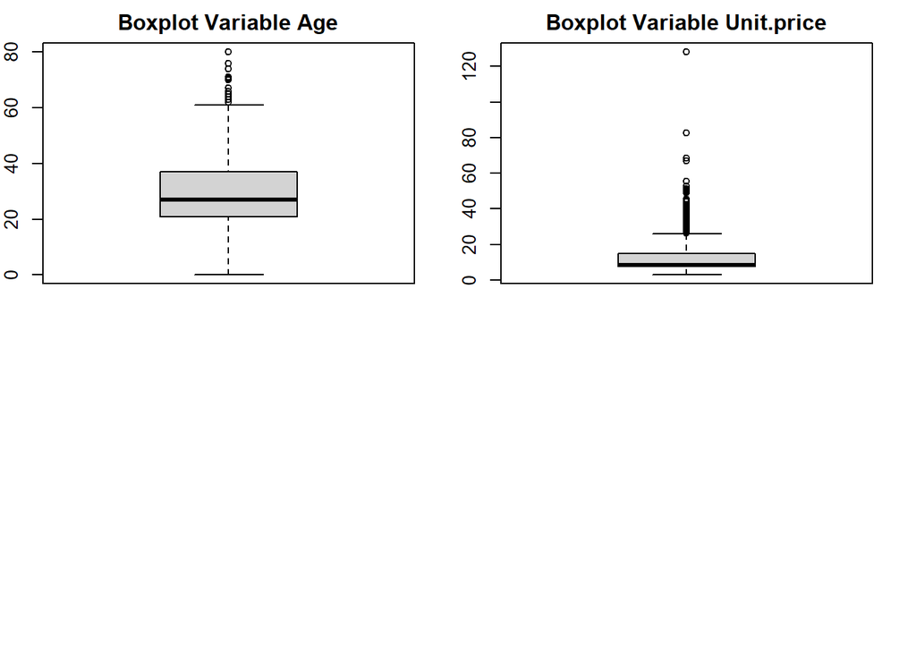

```r
boxplot.stats(df_total_sin_etiqueta$Unit.price, coef = 1.5, do.conf = TRUE, do.out = TRUE)
```

El boxplot muestra que hay outliers en estas dos variables. La mayoría de los pasajeros eran jóvenes, aunque también encontramos pasajeros de más de 65 años. En cuanto a la variable Unit.price, se comprueba que a medida que el precio sube, la clase va bajando de 3 a 2 y de 2 a 1, con lo cual no hay razón porqué pensar que los precios no son reales. En la tabla siguiente podemos visualizar algunos de los pasajeros que pagaron un precio de billete alto. Notamos que todos son de primera clase.

```r
# Muestra de varios precios de billetes unitarios en el rango alto
tail(df_total_sin_etiqueta[df_total_sin_etiqueta$Unit.price>30,], 15)
```

```
##      Pclass    Sex Age SibSp Parch Embarked Count.ticket Unit.price
## 1179      1   male  24     1     0        S            2   41.13335
## 1182      1   male  44     0     0        S            1   39.60000
## 1190      1   male  30     0     0        S            1   45.50000
## 1206      1 female  55     0     0        C            4   33.90832
## 1208      1   male  57     1     0        C            3   48.84027
## 1216      1 female  39     0     0        S            4   52.83438
## 1219      1   male  46     0     0        C            2   39.60000
## 1235      1 female  58     0     1        C            4  128.08230
## 1242      1 female  45     0     1        C            2   31.67915
## 1267      1 female  45     0     0        C            7   37.48214
## 1270      1   male  55     0     0        S            1   50.00000
## 1289      1 female  48     1     1        C            2   39.60000
## 1292      1 female  30     0     0        S            4   41.21668
## 1299      1   male  50     1     1        C            5   42.30000
## 1306      1 female  39     0     0        C            3   36.30000
```

Aunque se acepte que los precios son reales, es cierto que hay uno que es extremadamente alto y, aunque cierto, podría desvirtuar posibles futuras predicciones, por tanto se estima que se podría cambiar por la media de Unit.price agrupado por la primera clase, para tener un valor imputado más real.

```r
# Imputación del valor máximo de Unit.price
df_price_Pclass <- aggregate( df_total_sin_etiqueta$Unit.price ~ df_total_sin_etiqueta$Pclass, df_total_sin_etiqueta, mean )
mean_Unit.price <- df_price_Pclass[2][[1]][1]
```

```r
# Muestra de varios precios de billetes unitarios en el rango alto
max_Unit.price <- max(df_total_sin_etiqueta$Unit.price)
max_Unit.price
```

```
## [1] 128.0823
```

```r
df_total_sin_etiqueta$Unit.price[df_total_sin_etiqueta$Unit.price == max_Unit.price] <- mean_Unit.price
mean_Unit.price
```

```
## [1] 34.50998
```

```r
oldpar = par(mfrow = c(2,2), mar=c(2,2,2,2))

# Boxplot variable Age
boxplot(df_total_sin_etiqueta$Age, main="Boxplot Variable Age",ylab="Edad (años)")
print("Boxplot Stats Variable Age\n")
```

```
## [1] "Boxplot Stats Variable Age\n"
```

```r
boxplot.stats(df_total_sin_etiqueta$Age, coef = 1.5, do.conf = TRUE, do.out = TRUE)
```

```
## $stats
## [1]  0.17 21.00 27.00 37.00 61.00
##
## $n
## [1] 1309
##
## $conf
## [1] 26.30127 27.69873
##
## $out
##  [1] 66.0 65.0 71.0 65.0 70.5 62.0 63.0 65.0 64.0 65.0 63.0 71.0 64.0 62.0 62.0 80.0 65.0 70.0 70.0 62.0 74.0 62.0 63.0 67.0 65.0 76.0 63.0 64.0 64.0 64.0
```

```r
# Boxplot variable Age
boxplot(df_total_sin_etiqueta$Unit.price, main="Boxplot Variable Unit.price",ylab="Precio billete unitario")
print("Boxplot Stats Variable Fare\n")
```

```
## [1] "Boxplot Stats Variable Fare\n"
```

```
## $stats
## [1]  3.1708  7.7208  8.3000 15.0500 26.0000
##
## $n
## [1] 1309
##
## $conf
## [1] 7.979931 8.620069
##
## $out
##   [1] 35.64165 26.55000 26.55000 35.50000 43.83333 27.72080 48.84027 41.08540 30.98960 35.50000 40.00000 41.73750 27.72080 43.83333 30.58750 34.65420 31.67915 38.64375 82.50693 38.64375 26.28330 26.55000 39.60000 33.30000 30.68960 27.50000 33.50000 30.69580 28.71250 50.00000 26.55000 27.72080 48.…
##  [56] 28.46460 27.71943 37.48214 41.21668 26.90000 33.90832 28.98960 28.50000 51.15417 66.82500 33.30000 26.90000 35.50000 43.83333 35.00000 27.50000 37.62500 34.65000 27.72085 33.90832 41.08540 42.30000 45.50500 30.00000 37.75833 30.00000 26.55000 27.95000 30.00000 43.83333 27.28610 26.55000 30.…
## [111] 49.50000 35.50000 35.47500 27.72083 26.55000 39.60000 45.50500 26.55000 26.38750 27.95000 27.72083 40.12500 26.55000 39.60000 39.13335 28.46460 26.55000 30.50000 51.15417 26.27710 32.32080 30.00000 30.50000 34.65000 35.50000 37.75833 66.82500 34.50998 52.83438 28.50000 26.55000 27.72083 45.…
## [166] 31.68330 26.55000 26.55000 31.68330 40.00000 27.71943 29.70000 44.55210 41.21668 26.55000 50.49580 26.27710 27.71943 30.00000 30.00000 41.13335 30.58750 29.70000 31.68330 30.68960 37.48214 30.98960 30.50000 28.87500 26.55000 26.27710 29.70000 38.14585 30.00000 43.83333 37.48214 37.48214 28.…
## [221] 27.71943 26.55000 82.50693 26.90000 45.50500 27.72080 42.50000 41.21668 42.30000 27.44580 26.55000 35.64165 37.62500 35.47500 27.72080 26.90000 68.38960 37.62085 68.38960 41.13335 39.60000 27.28610 45.50000 26.55000 33.90832 48.84027 26.55000 52.83438 39.60000 29.70000 34.50998 31.67915 27.…
```

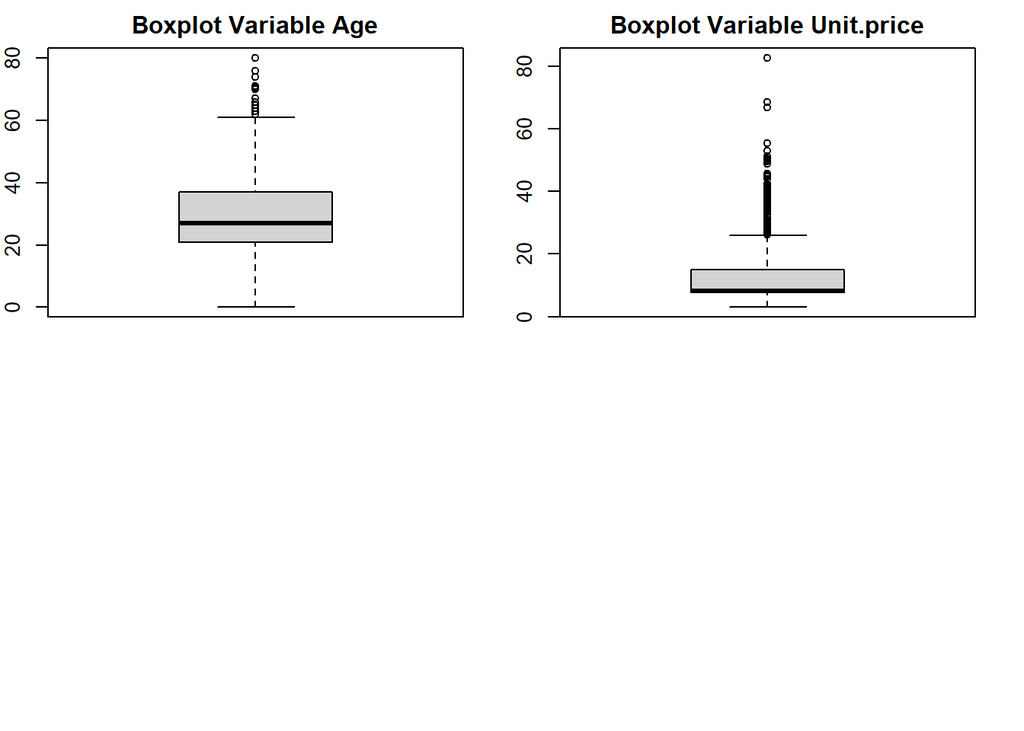

```r
boxplot.stats(df_total_sin_etiqueta$Unit.price, coef = 1.5, do.conf = TRUE, do.out = TRUE)
```

# 4 **Análisis de datos**

Una vez limpiado el archivo que contenía las líneas de los conjuntos train y test, deberemos separar otra vez los conjuntos ya que únicamente tenemos datos de la etiqueta para el conjunto de entrenamiento.

```r
# Guardamos en disco el archivo global
write.csv(df_total_sin_etiqueta, "Titanic_global_sin_etiqueta.csv", row.names = FALSE)
```

```r
# Creación del conjunto de train y test después de la limpieza del dataset
train <- df_total_sin_etiqueta[1:train_rows, ]
test <- df_total_sin_etiqueta[(train_rows + 1):(train_rows+test_rows), ]
```

Y añadimos las etiquetas al conjunto de train:

```r
# Adición de las etiquetas al conjunto de entrenamiento
train <- cbind(train, etiquetas )
```

Guardamos en disco los archivos train y test procesados y “limpios” preparados para su posterior análisis.

```r
# Guardamos en disco los archivos procesados
write.csv(train, "train_processed.csv", row.names = FALSE)
write.csv(test, "test_processed.csv", row.names = FALSE)
```

**Screening**

Antes de crear las visualizaciones determinamos que las variables numéricas son: Age y Unit.price que corresponden a la edad de los pasajeros y el precio unitario del billete.

**OLGA: revisar aquí, si las variables son categóricas o no, parece que nos va mejor que no lo sean** Survived, Sex, Embarked son variables categóricas y Pclass, SibSp, Parch son variables categóricas ordinales (existen rangos en los valores de las variables).

Realizamos las transformaciones oportunas para guardar las variables con sus tipos correspondientes.

```r
# Categóricas
train$Survived <- as.factor(train$Survived)
train$Sex <- as.factor(train$Sex)

# Categóricas ordinales
#train$Pclass <- factor(train$Pclass, levels= c(1, 2, 3))
#train$SibSp <- factor(train$SibSp, levels = c(0, 1, 2, 3, 4, 5, 8))
#train$Parch <- factor(train$Parch, levels = c(0, 1, 2, 3, 4, 5, 6, 9))
```

Creamos una función que nos facilite visualizar las distribuciones de las variables, así como detectar posibles valores extremos.

```r
visualiz <- function(data, colm, facet.colm, title, facetPlot=FALSE){
oldpar = par(mfrow = c(2,2), mar=c(2,2,2,2))
truehist(data[[colm]], main = title)
abline(v = mean(data[[colm]]), col="red", lwd=3, lty=2);
abline(v = median(data[[colm]]), lwd=3, lty=2, col="blue");
qqnorm(data[[colm]], main = title);qqline(data[[colm]], col = 2 )
if (facetPlot==TRUE) {
  boxplot(data[[colm]]~data[[facet.colm]], main = paste("Survived by", title))
}

boxplot(data[[colm]], main = title)
}
```

**Visualización de las variables numéricas**

Los pasajeros que tienen edades entre los cuantiles 25 y 75 tienen entre 20 y 40 años. La edad mediana para los pasajeros que sobrevivieron y los que no es muy similar.

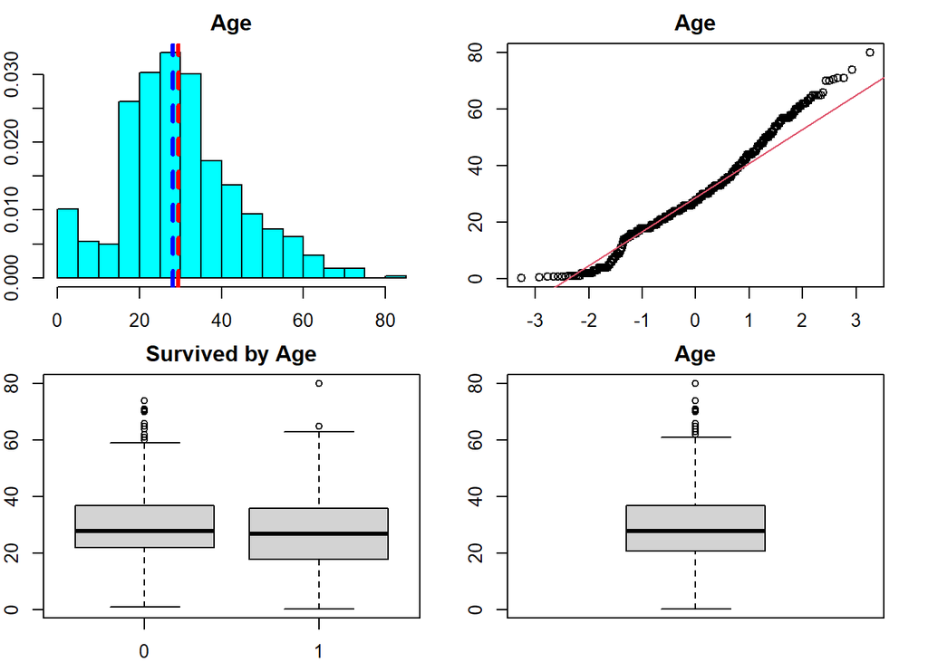

```r
visualiz(train, "Age", "Survived", "Age", facetPlot=TRUE)
```

Si vemos la variable Unit.price (precio unitario del billete), la mayoría de los pasajeros pagaron muy poco por el billete. Aquí en el boxplot encontramos outliers pero consideramos que no deberíamos descartar estas entradas ya que hay pocos pasajeros que pagaron un importe alto por el billete y esta información puede ser muy interesante para predecir la posibilidad de supervivencia: ¿Viajar en una clase privilegiada aumenta la posibilidad de sobrevivir?

En el boxplot además podemos ver que las personas que sobreviven tienen una mediana más alta en el precio del billete.

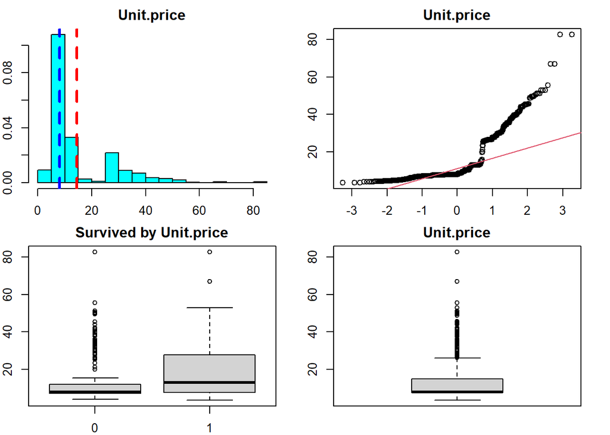

```r
visualiz(train, "Unit.price", "Survived", "Unit.price", facetPlot=TRUE)
```

A continuación visualizamos los datos para las variables Class, Sex, Siblings/Spouse, Parents/Children

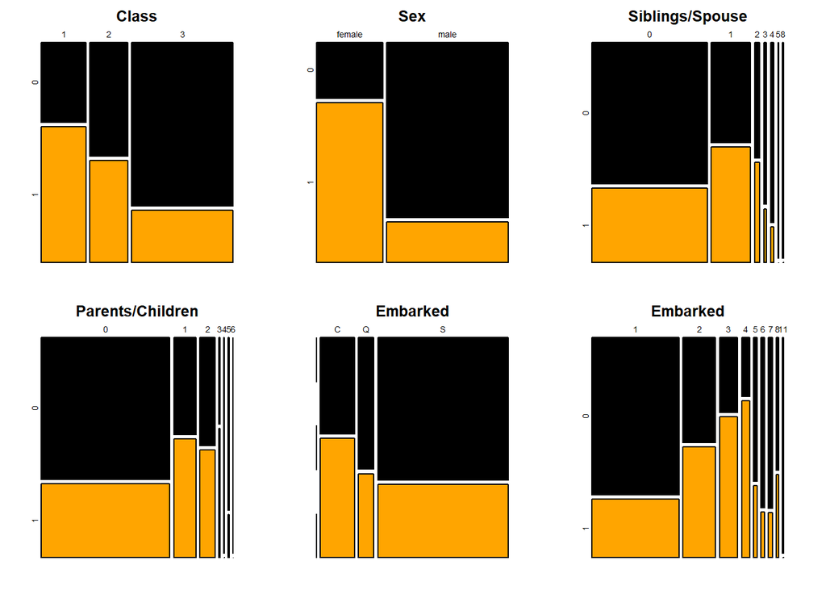

```r
oldpar = par(mfrow = c(2,3), mar=c(2,2,2,2))

plot(table(train$Pclass, train$Survived), col = c("black", "orange"), main="Class")

plot(table(train$Sex, train$Survived), col = c("black", "orange"), main="Sex")

plot(table(train$SibSp, train$Survived), col = c("black", "orange"), main="Siblings/Spouse")

plot(table(train$Parch, train$Survived), col = c("black", "orange"), main="Parents/Children")

plot(table(train$Embarked, train$Survived), col = c("black", "orange"), main="Embarked")

plot(table(train$Count.ticket, train$Survived), col = c("black", "orange"), main="Embarked")
```

Las personas que viajaban en tercera clase tienen la menor proporción de supervivencia comparando con las personas que viajaban en primera clase. Las mujeres que viajaban en el titanic sobrevivieron en su mayoría. Los hombres sobrevivieron en mucho menor proporción.

La mayoría de personas viajaba sin familiares (hermanos, pareja, padres o hijos) y parece ser que el porcentaje de supervivencia es algo más alto en personas que tenían familiares a bordo.

La mayoría de personas embarcaron en el punto S, pero el mayor porcentaje de supervivencia lo tienen las personas que embarcaron en C.

**Análisis bivariable**

Vamos a visualizar algunos plots que nos permiten ver la supervivencia de pasajeros combinando dos variables.

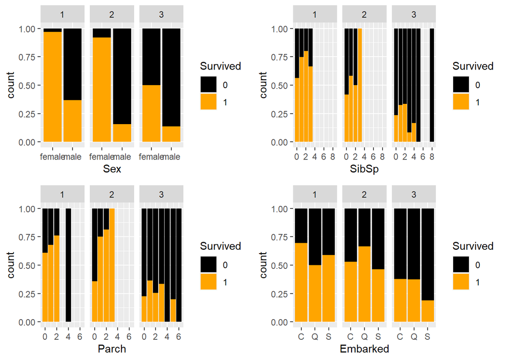

```r
grid.newpage()

sex.class <- ggplot(data=train, aes(x=Sex, fill=Survived))+geom_bar(position = 'fill')+facet_wrap(~Pclass)+ scale_fill_manual(values=c("black", "orange"))
sibs.class <- ggplot(data=train, aes(x=SibSp, fill=Survived))+geom_bar(position = 'fill')+facet_wrap(~Pclass)+ scale_fill_manual(values=c("black", "orange"))
parch.class <- ggplot(data=train, aes(x=Parch, fill=Survived))+geom_bar(position = 'fill')+facet_wrap(~Pclass)+ scale_fill_manual(values=c("black", "orange"))
embark.class <- ggplot(data=train, aes(x=Embarked, fill=Survived))+geom_bar(position = 'fill')+facet_wrap(~Pclass)+ scale_fill_manual(values=c("black", "orange"))

grid.arrange(sex.class, sibs.class, parch.class, embark.class,  ncol=2)
```

Las mujeres que viajaban en primera y segunda clase sobrevivieron casi todas. Los hombres sobrevivieron en mucho menor medida, incluso los hombres que viajaron en primera clase.

Las personas que viajaban con hermanos o pareja en primera clase sobrevivieron en mayor medida que las personas que viajaron solas. En primera y segunda clase no hay personas que viajasen con más de 3 hermanos. En tercera clase hay personas que viajaron con hasta 8 hermanos en este caso un menor número de hermanos (excepto cero) parece indicar una mayor supervivencia.

También hemos visualizado la supervivencia en función del lugar donde los pasajeros embarcaron en el Titanic. Los pasajeros de tercera clase que embarcaron en el punto S han tenido menos proporción de supervivencia que los demás. Los pasajeros de segunda clase que embarcaron en Q sobrevivieron en mayor proporción que los pasajeros de segunda clase que embarcaron en otros puntos. Para los pasajeros de primera clase el punto de embarque con mayor porcentaje de superviviencia es C.

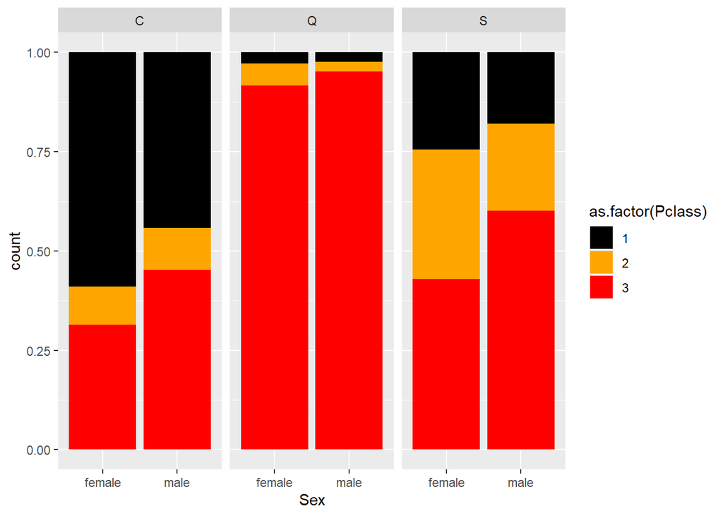

```r
ggplot(data=train, aes(x=Sex, fill=as.factor(Pclass)))+geom_bar(position = 'fill')+facet_wrap(~Embarked)+ scale_fill_manual(values=c("black", "orange", "red"))
```

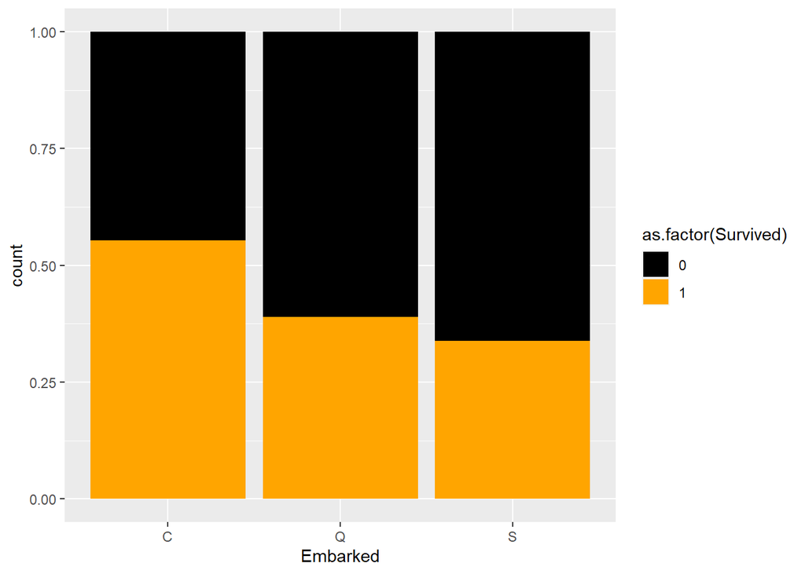

```r
ggplot(data=train, aes(x=Embarked, fill=as.factor(Survived)))+geom_bar(position = 'fill')+ scale_fill_manual(values=c("black", "orange", "red"))
```

Visualizamos la supervivencia usando las variables de la clase en la que viaja el pasajero y el número de personas que viajan con el mismo billete.

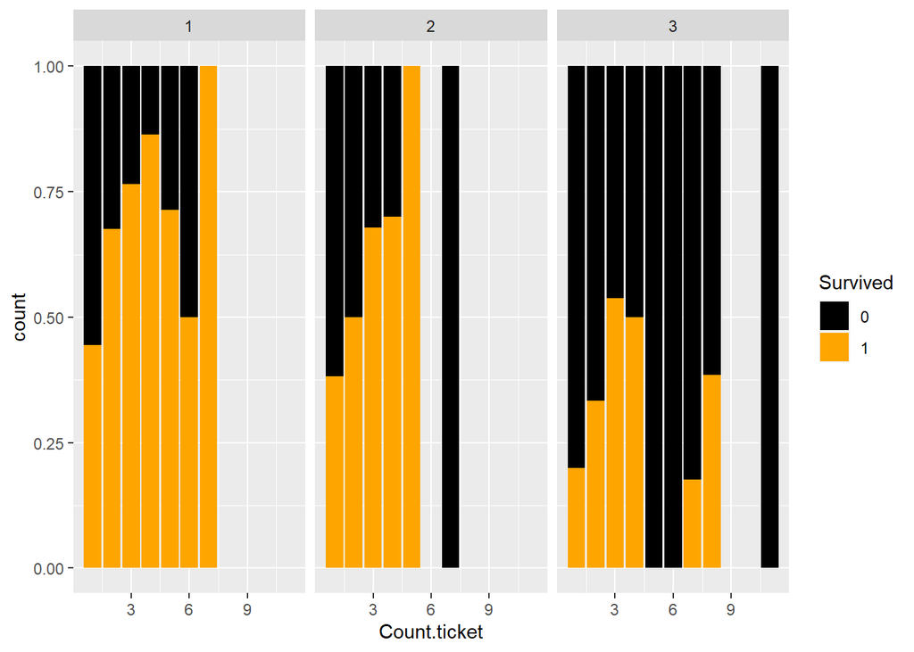

```r
ggplot(data=train, aes(x=Count.ticket, fill=Survived))+geom_bar(position = 'fill')+facet_wrap(~Pclass)+ scale_fill_manual(values=c("black", "orange", "red"))
```

## 4.1 Análisis de los datos.

### 4.1.1 Selección de los grupos de datos que se quieren analizar/comparar (planificación de los análisis a aplicar).

La pregunta que planteamos inicialmente es si entre las variables que tenemos en el dataset existen algunas que influyen en mayor medida en la supervivencia de los pasajeros del Titanic. En los análisis anteriores hemos comprobado visualmente que las personas de primera clase han sobrevivido en mayor medida, que las mujeres y los niños tienen una mayor proporción de supervivencia. También hemos visto que personas que viajan acompañadas, ya sea por familia o amigos, tiene una proporcion de supervivencia algo mejor.

Vamos a usar estos datos para analizar el dataset en mayor profundidad. Para ello necesitamos datasets especializados.

**CARLOS: NO VEO PQ NO HACEMOS UN GRUPO CON LA PCLASS 3** **Olga: NO hay pomivo por el que no hacer class3, pero pensaba que nos ibamos a centrar en con cuantos viajan y dejar lo demás de lado.. no sé**

OLGA: Si seguimos con lo que hemos hablado, de centrarnos en si los pasajeros viajan solos o no, debemos separar estos 3 pares de datasets.**las variables sibsp, parch están como factor, voy a comentar la parte donde se les transforma en factor..**

```r
# Dataframe por pasajeros que viajaban solos o acompañados
train.single <- train[train$Count.ticket=="1",]
train.many <- train[train$Count.ticket>1,]
```

```r
# Dataframe por pasajeros que viajaban solos o acompañados
train.spouse <- train[train$SibSp>0,]
train.not.spouse <- train[train$sibsp==0,]
```

```r
# Dataframe por pasajeros que viajaban solos o acompañados
train.children <- train[train$Parch>10,]
train.no.children <- train[train$Parch==0,]
```

```r
# Dataframes por clase de pasajero
train.first <- train[train$Pclass==1,]
train.second <- train[train$Pclass==2,]
train.first.second <- train[train$Pclass==1 | train$Pclass==2,]
train.first.second$Pclass <- factor(train.first.second$Pclass, levels = c(1,2))
```

```r
# Dataframe por sexo del pasajero
train.male <- train[train$Sex=="male", ]
train.female <- train[train$Sex=="female",]
```

```r
# Dataframe por edad del pasajero
train.young <- train[train$Age<18,]
train.older <- train[train$Age>=18,]
```

```r
train.survived <- train[train$Survived==1,]
train.not.survived <- train[train$Survived==0,]
```

### 4.1.2 Comprobación de la normalidad y homogeneidad de la varianza.

**Normalidad**

```r
 visualiz1 <- function(D1, D2, name1, name2, title){
   oldpar = par(mfrow = c(2,2), mar=c(2,2,2,2))
  truehist(D1, main = paste(name1," ", title))
  abline(v = mean(D1), col="red", lwd=3, lty=2);
  abline(v = median(D1), lwd=3, lty=2, col="blue");
  qqnorm(D1, main = paste(name1, " ", title));qqline(D1, col = 2 )
  truehist(D2, main = paste(name2," ", title))
  abline(v = mean(D2), col="red", lwd=3, lty=2);
  abline(v = median(D2), lwd=3, lty=2, col="blue");
  qqnorm(D2, main = paste(name2," ", title)); qqline(D2, col = 2 )

}
```

**Variable age**

Visualizamos los datos de la edad para personas que sobrevivieron en el hundimiento frente a personas que no sobrevivieron.

La media y la mediana de los pasajeros que sobrevivieron están muy cerca. Las personas que no sobrevivieron tienen una edad mediana más baja que la edad media. Los valores de estos dos indicadores de tendencia central son más altos para personas que no sobrevivieron: las personas que muerieron tenían una media de edad algo más alta que los que sobrevivieron.

Según el qqplot las dos distribuciones son cercanas a la normal. Según el teorema del límite central podemos asumir la distribución normal de la media de estas dos muestras ya que sus tamaños son mayores que 30 observaciones.

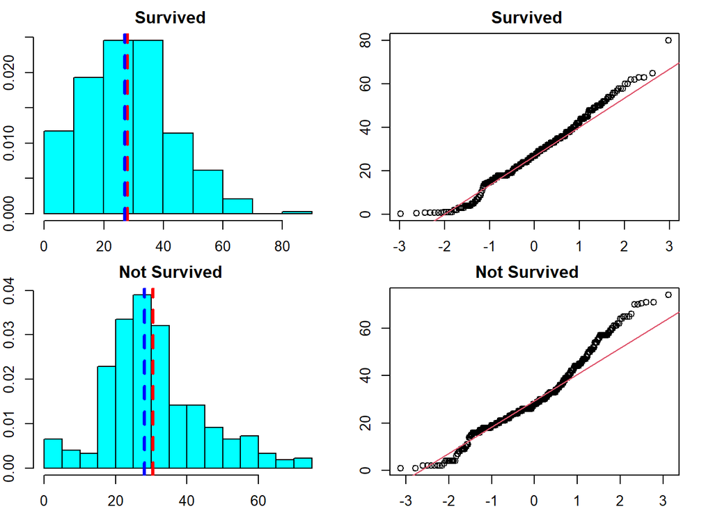

```r
visualiz1(train.survived$Age, train.not.survived$Age, "Survived", "Not Survived", "")
```

Comprobaremos de la igualdad de las varianzas entre los conjuntos de datos de pasajeros que sobrevivieron y no. Para ello usamos la función `var.test`.

El contraste de varianzas se realiza mediante un contraste de hipótesis, donde aceptar H0 significaría que las varianzas son iguales.

El valor p-value que obtenemos es de 0.15. Este valor indica que rechazando la hipótesis nula de igualdad de varianzas probablemente estaríamos comentiendo un error. Las varianzas en la edad de los pasajeros que sobrevivieron y los que no sobrevivieron son iguales y podemos hacer esta afirmación con un nivel de confianza del 95%.

```r
var.test(train.survived$Age, train.not.survived$Age)
```

```
##
##  F test to compare two variances
##
## data:  train.survived$Age and train.not.survived$Age
## F = 1.1489, num df = 341, denom df = 548, p-value = 0.1508
## alternative hypothesis: true ratio of variances is not equal to 1
## 95 percent confidence interval:
##  0.9507576 1.3943200
## sample estimates:
## ratio of variances
##           1.148887
```

**Variable Unit price: precio del billete unitario**

Visualizamos el precio del billete unitario para los pasajeros que sobrevivieron frente a los que no. Podemos ver que la media y la mediana del precio de billete para los pasajeros que sobrevivieron están bastante separadas. El precio que corresponde a la mediana es alrededor de 13 y la media es más cercana a 20. Existe esta diferencia porque la distribución tiene una cola larga a la derecha, tenemos pasajeros que pagaron un precio muy alto por sus billetes.

La mayoría de los pasajeros que no sobrevivieron pagaron un precio bajo por el billete, hay pocas personas que pagaron precios más altos y no sobrevivieron.

Ninguna de las dos distribuciones es normal, aunque para el fin de hacer un contraste de hipótesos sobre la media podemos asumir que la media poblacional se distribuye normalmente (teorema del límite central).

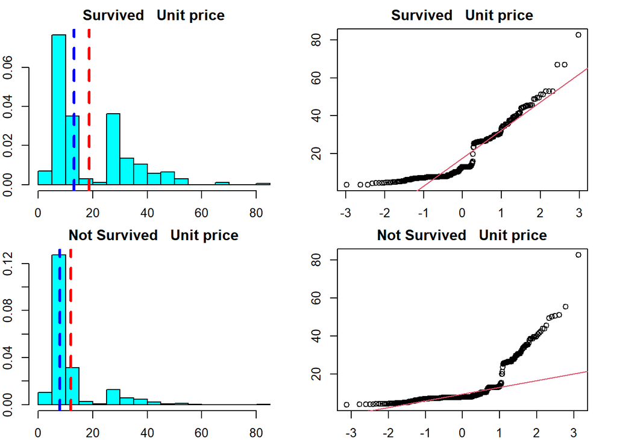

```r
visualiz1(train.survived$Unit.price, train.not.survived$Unit.price, "Survived", "Not Survived", "Unit price")
```

Realizamos el test de igualdad de las varianzas para el precio del billete para pasajeros que sobrevivieron frente a los que no sobrevivieron. El valor p nos indica que podemos rechazar H0, es decir, las varianzas entre estos dos grupos de pasajeros son diferentes.

En los histogramas podemos ver que los pasajeros que sobrevivieron de media pagaron más por sus billetes. Tanto en el grupo de supervivientes como de no supervivientes la media es mayor que la mediana, dado que tenemos outliers de precio de billete unitario muy alto.

```r
var.test(train.survived$Unit.price, train.not.survived$Unit.price)
```

```
##
##  F test to compare two variances
##
## data:  train.survived$Unit.price and train.not.survived$Unit.price
## F = 2.0651, num df = 341, denom df = 548, p-value = 3.73e-14
## alternative hypothesis: true ratio of variances is not equal to 1
## 95 percent confidence interval:
##  1.708968 2.506262
## sample estimates:
## ratio of variances
##           2.065101
```

**Variable SibSp: pareja o hermanos**

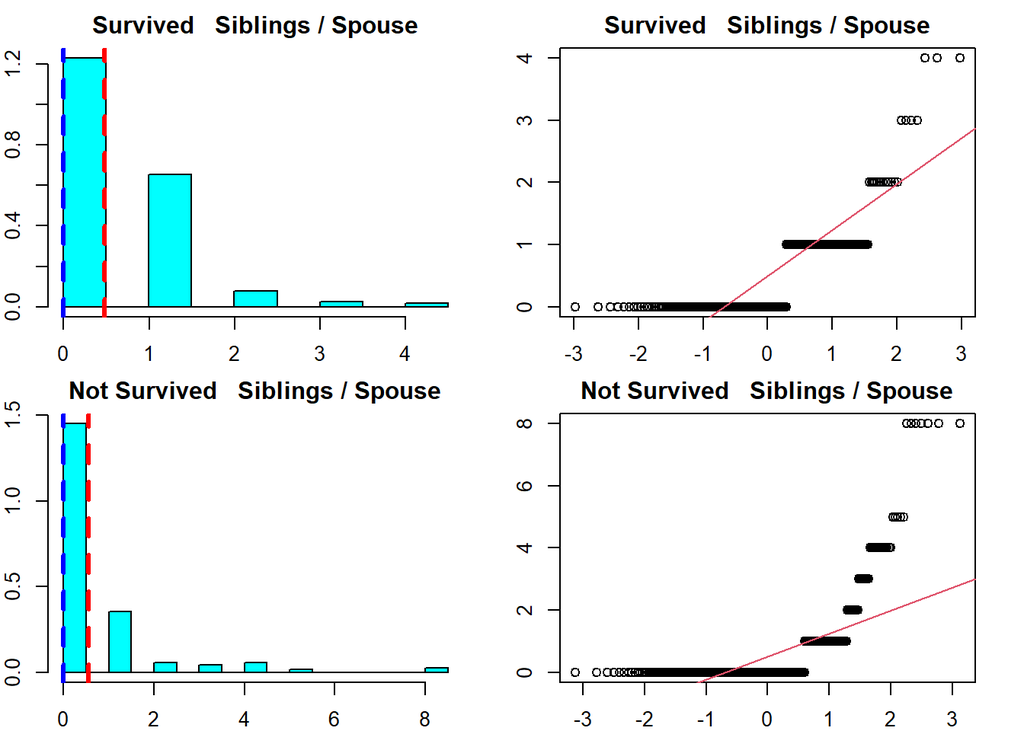

```r
visualiz1(train.survived$SibSp, train.not.survived$SibSp, "Survived", "Not Survived", "Siblings / Spouse")
```

```r
var.test(train.survived$SibSp, train.not.survived$SibSp)
```

```
##
##  F test to compare two variances
##
## data:  train.survived$SibSp and train.not.survived$SibSp
## F = 0.30256, num df = 341, denom df = 548, p-value < 2.2e-16
## alternative hypothesis: true ratio of variances is not equal to 1
## 95 percent confidence interval:
##  0.2503810 0.3671926
## sample estimates:
## ratio of variances
##          0.3025581
```

**Variable Parch: padres o hijos**

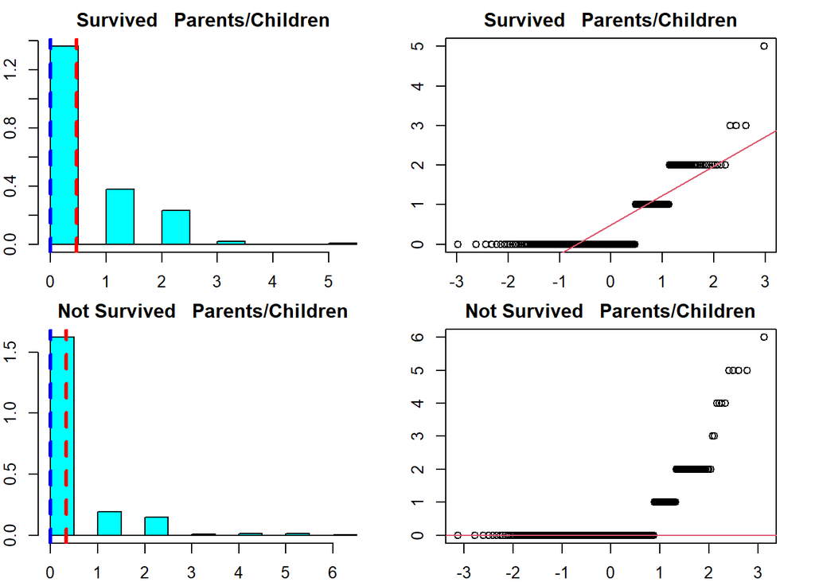

```r
visualiz1(train.survived$Parch, train.not.survived$Parch, "Survived", "Not Survived", "Parents/Children")
```

El test de igualdad de las varianzas indica que no podemos rechazar la hipótesis nula. Entre los grupos que sobrevivieron y los que no sobrevivieron las varianzas de la variable Parch son iguales.

```r
var.test(train.survived$Parch, train.not.survived$Parch)
```

```
##
##  F test to compare two variances
##
## data:  train.survived$Parch and train.not.survived$Parch
## F = 0.87889, num df = 341, denom df = 548, p-value = 0.1908
## alternative hypothesis: true ratio of variances is not equal to 1
## 95 percent confidence interval:
##  0.7273246 1.0666475
## sample estimates:
## ratio of variances
##          0.8788923
```

**Variable Count.ticket: número de personas que viajaban con un mismo billete**

Visualizamos un histograma que muestra la frecuencia de recuento de billetes: pasajeros que viajaban solos hasta pasajeros que viajaban con muchos acompañantes.

La media para el recuento de billetes es de 2 mientras que la mediana es 1.

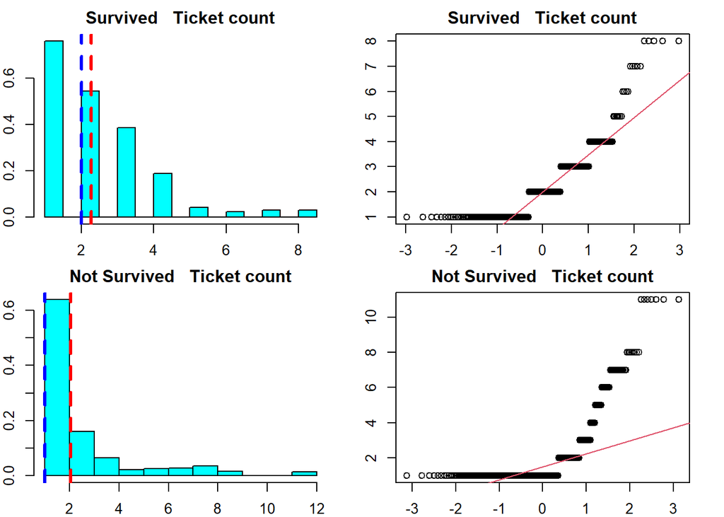

```r
visualiz1(train.survived$Count.ticket, train.not.survived$Count.ticket, "Survived", "Not Survived", "Ticket count")
```

En este caso tenemos un valor p muy bajo y por lo tanto podemos aceptar H1 que indica que las varianzas de la variable Count.ticket son diferentes en el grupo de supervivientes y no supervivientes.

```r
var.test(train.survived$Count.ticket, train.not.survived$Count.ticket)
```

```
##
##  F test to compare two variances
##
## data:  train.survived$Count.ticket and train.not.survived$Count.ticket
## F = 0.55183, num df = 341, denom df = 548, p-value = 3.459e-09
## alternative hypothesis: true ratio of variances is not equal to 1
## 95 percent confidence interval:
##  0.4566685 0.6697206
## sample estimates:
## ratio of variances
##          0.5518339
```

### 4.1.3 Aplicación de pruebas estadísticas para comparar los grupos de datos. En función de los datos y el objetivo del estudio, aplicar pruebas de contraste de hipótesis, correlaciones, regresiones, etc. Aplicar al menos tres métodos de análisis diferentes.

**Contraste de hipótesis sobre el sexo y nivel de supervivencia**

¿La proporción de supervivencia en hombres es inferior a la de las mujeres?

Acorde con la pregunta planteada, realizaremos un contraste de hipótesis con las siguientes hipótesis de partida:

Hipótesis nula - H0: La proporción de hombres que sobreviven es igual o mayor a 50% -> H0: p >= p0, siendo p0 = 0.5  
Hipótesis alternativa - H1: La proporción de hombres es menor a 50% -> H1: p < p0, siendo po = 0.5

Este contraste de hipótesis representa un test de la proporción de la población por la cola izquierda, por tanto, el valor p0 representará, bajo la hipótesis nula, el límite inferior de la supuesta verdadera proporción de la población.  
Este contraste rechazará la HO si el estadístico calculado es menor o igual al valor crítico (con signo negativo) al nivel de significación estimado.

El hecho que la proporción de hombres que sobreviven sea menor que 0.5, implicaría que la proporción de hombres que sobreviven es inferior a la de las mujeres.

Debido a que es un contraste de hipótesis sobre proporción de una muestra, y esta muestra es considerada grande (n > 30), podremos definir un estadístico de contraste como una observación de una variable aleatoria que se distribuye aproximadamente como una N(0,1).

Debido al planteamiento de la hipótesis nula y su alternativa y por cómo se han descrito las hipótesis H0 y H1, se observa que la hipótesis alternativa es unilateral, puesto que se plantea como un límite a un solo valor dado.

```r
# Fijamos un nivel de significación

alfa <- 0.05
```

Determinamos el estadístico de contraste, en este caso, la muestra es grande y proviene de una distribución de Bernoulli de parámetro p, con lo cual, según el Teorema del Límite Central podremos utilizar el estadístico de contraste mostrado anteriormente.

```r
# Determinación del estadístico de contraste

train.survived_M <- train.survived[train.survived$Sex=="male",]
train.survived_F <- train.survived[train.survived$Sex=="female",]



n_Sex <- length(train.survived$Sex)

n_Sex_M <- length(train.survived_M$Sex)

n_Sex_F <- length(train.survived_F$Sex)



# Proporción muestral de hombres
p_hat <- n_Sex_M/n_Sex


# Proporción hipotesis nula
p_0 <- 0.5


# Estadístico empleado z_p
z_p = (p_hat - p_0)/sqrt(p_0 * (1 - p_0)/n_Sex)

# Cálculo de valores críticos para el valor de significación asignado

z_p.alfa = qnorm(1-alfa)


# Cálculo del valor P en nuestro contraste de hipótesis

valor_p_Sex = pnorm(z_p)


data.frame(n_Sex, n_Sex_M, n_Sex_F, p_hat, p_0, z_p, -z_p.alfa, valor_p_Sex)
```

```
##   n_Sex n_Sex_M n_Sex_F     p_hat p_0       z_p X.z_p.alfa  valor_p_Sex
## 1   342     109     233 0.3187135 0.5 -6.705152  -1.644854 1.005984e-11
```

Tal y como se ha planteado H0 y H1, siendo H1 p < 0.5, rechazaremos H0 si el valor del estadístico z_p es menor que el valor crítico (en signo negativo), siendo este el caso -6.70 < -1.64.

Según el estadístico de contraste utilizado y el valor crítico calculado, al ser el primero (-6.70) menor que el segundo (-1.64), al 0.05 de nivel de significancia, podemos rechazar la hipótesis nula de que la proporción de supervivencia en hombres es mayor o igual a 50% respecto al de las mujeres.

De igual forma, al ser valor p casi nulo y por tanto menor que nuestro nivel de significación (0.05), el valor p es significativo y podemos rechazar, confirmando el contraste anterior, la hipótesis nula.

Siguiendo la misma metodología, responderemos a las siguientes preguntas:

**¿La proporción de supervivencia en menores es inferior a la de los mayores?**

Hipótesis nula - H0: La proporción de menores que sobreviven es igual o mayor a 50% -> H0: p >= p0, siendo po = 0.5  
Hipótesis alternativa - H1: La proporción de menores es menor a 50% -> H1: p < p0, siendo po = 0.5

```r
# Determinación del estadístico de contraste

train.survived_Y <- train.survived[train.survived$Age<18,]
train.survived_O <- train.survived[train.survived$Age>=18,]


n_Age <- length(train.survived$Age)

n_Age_Y <- length(train.survived_Y$Age)

n_Age_O <- length(train.survived_O$Age)



# Proporción muestral de menores
p_hat <- n_Age_Y/n_Age


# Proporción hipotesis nula
p_0 <- 0.5

# Estadístico empleado z_p
z_p = (p_hat - p_0)/sqrt(p_0 * (1 - p_0)/n_Age)

# Cálculo de valores críticos para el valor de significación asignado

z_p.alfa = qnorm(1-alfa)

# Cálculo del valor P en nuestro contraste de hipótesis

valor_p_Age = pnorm(z_p)

data.frame(n_Age, n_Age_Y, n_Age_O, p_hat, p_0, z_p, -z_p.alfa, valor_p_Age)
```

```
##   n_Age n_Age_Y n_Age_O     p_hat p_0       z_p X.z_p.alfa  valor_p_Age
## 1   342      70     272 0.2046784 0.5 -10.92291  -1.644854 4.478993e-28
```

De igual forma, al ser valor p casi nulo y por tanto menor que nuestro nivel de significación (0.05), el valor p es significativo y podemos rechazar, confirmando el contraste anterior, la hipótesis nula.

**¿La proporción de supervivencia en viajeros con billete único es inferior a la de los viajeros con billete en conjunto?**

Hipótesis nula - H0: La proporción de viajeros con billete único que sobreviven es igual o mayor a 50% -> H0: p >= p0, siendo po = 0.5  
Hipótesis alternativa - H1: La proporción de viajeros con billete único es menor a 50% -> H1: p < p0, siendo po = 0.5

```r
# Determinación del estadístico de contraste

train.survived_S <- train.survived[train.survived$Count.ticket==1,]
train.survived_My <- train.survived[train.survived$Count.ticket>1,]

n_Count.ticket <- length(train.survived$Count.ticket)

n_Count.ticket_S <- length(train.survived_S$Count.ticket)

n_Count.ticket_My <- length(train.survived_My$Count.ticket)



# Proporción muestral de menores
p_hat <- n_Count.ticket_S/n_Count.ticket

# Proporción hipotesis nula
p_0 <- 0.5

# Estadístico empleado z_p
z_p = (p_hat - p_0)/sqrt(p_0 * (1 - p_0)/n_Count.ticket)

# Cálculo de valores críticos para el valor de significación asignado

z_p.alfa = qnorm(1-alfa)

# Cálculo del valor P en nuestro contraste de hipótesis

valor_p_Count.ticket = pnorm(z_p)

data.frame(n_Count.ticket, n_Count.ticket_S, n_Count.ticket_My, p_hat, p_0, z_p, -z_p.alfa, valor_p_Count.ticket)
```

```
##   n_Count.ticket n_Count.ticket_S n_Count.ticket_My    p_hat p_0       z_p X.z_p.alfa valor_p_Count.ticket
## 1            342              130               212 0.380117 0.5 -4.434052  -1.644854         4.623911e-06
```

De igual forma, al ser valor p casi nulo y por tanto menor que nuestro nivel de significación (0.05), el valor p es significativo y podemos rechazar, confirmando el contraste anterior, la hipótesis nula.

**Relación entre supervivencia y billete único o grupal**

El test se aplica en R con un nivel de confianza por defecto del 95%.

Crearemos dos tablas de contingencia entre las variables que indican supervencia y la que indica el tipo de billete. Una primera en valores absolutos, y una segunda mostrando las proporciones.

```r
# Tabla de contingencia Survived - Tipo Billete

train$ticket_tipo[train$Count.ticket==1] = "Único"
train$ticket_tipo[train$Count.ticket!=1] = "Grupal"

train$ticket_tipo <- as.factor(train$ticket_tipo)
table(train$Survived, train$ticket_tipo, dnn = c("Supervivencia", "Tipo Billete"))
```

```
##              Tipo Billete
## Supervivencia Grupal Único
##             0    198   351
##             1    212   130
```

```r
# Tabla de contingencia en proporciones Survived - Tipo Billete
prop.table(table(train$Survived, train$ticket_tipo, dnn = c("Supervivencia (%)", "Tipo Billete (%)")))
```

```
##                  Tipo Billete (%)
## Supervivencia (%)    Grupal     Único
##                 0 0.2222222 0.3939394
##                 1 0.2379349 0.1459035
```

```r
length(train$ticket_tipo)
```

```
## [1] 891
```

```r
length(train$Survived)
```

```
## [1] 891
```

Dos variables categóricas que forman parte de una tabla de contingencia pueden ser sujetas a un test de independencia. Este test puede ser representado for el ChiSquare Test mediante un contraste de hipótesis.

El contraste se realizará para observar si las dos variables son independientes o no, por tanto, podemos plantear las hipótesis como se indica a continuación:

Hipótesis nula - H0: Las variables Survived y Tipo Billete son independientes.  
Hipótesis alternativa - H1: Las variables Survived y Tipo Billete están relacionadas.

```r
# Tabla de contingencia Survived y Tipo Billete
tabla_cont <- table(train$Survived, train$ticket_tipo, dnn = c("Supervivencia", "Tipo Billete"))
tabla_cont
```

```
##              Tipo Billete
## Supervivencia Grupal Único
##             0    198   351
##             1    212   130
```

```r
# Comprobación con la función chisq.test()
chisq.test(tabla_cont)
```

```
##
##  Pearson's Chi-squared test with Yates' continuity correction
##
## data:  tabla_cont
## X-squared = 55.966, df = 1, p-value = 7.375e-14
```

El cálculo de los grados de libertad para una distribución Chi Square se calcula como df = (c - 1)(r - 1) donde c es el número´de columnas y r el número de filas. En nuestro caso c = r = 2, por lo tanto df = (2 - 1)(2 - 1) = 1.

```r
# Grados de libertad

gdl <- 1

# Nivel de confianza

ndc <- 0.95


# Valor Crítico
val_cri <- qchisq(ndc, gdl)
val_cri
```

```
## [1] 3.841459
```

Debido a que el estadístico Chi Square es mayor al valor crítico calculado de la distribución Chi Square (con un grado de libertad y con un nivel de significación de 0.05), podemos rechazar la hipótesis nula de que no hay relación entre Survived y Tipo de Billete, es decir, rechazamos la hipótesis al 95 % de nivel de confianza de que tales variables sean independientes.

Como el valor de p es menor que el nivel de significancia, podemos rechazar la hipótesis nula de que las variables Survived y Tipo de Billete son independientes, cuadrando este resultado con los cálculos anteriores.

Por tanto, se puede afirmar al 95% de nivel de confianza que las variables Survived y Tipo de Billete **están relacionadas**.

**Contraste de hipótesis sobre la edad de supervivencia**

Planteamos la pregunta de investigación: Queremos saber si las personas que sobrevivieron eran más jóvenes que las personas que murieron en el accidente o, por el contrario, la edad para las personas que muerieron y sobrevivieron es similar.

H0: La media de edad de las personas supervivientes es la misma que de las personas que muerieron  
H1: La media de edad de las personas que murieron es mayor que la de las personas supervivientes.

Usamos un test paramétrico definido por `t.test`

Con un valor p-value igual por debajo de 0.05 podemos aceptar la hipótesis H1. Con un nivel de confianza del 95% afirmamos que las personas que murieron en el Titanic tienen una media de edad más alta que las personas que sobrevivieron.

```r
t.test(train.not.survived$Age, train.survived$Age, alternative="greater", var.equal=TRUE)
```

```
##
##  Two Sample t-test
##
## data:  train.not.survived$Age and train.survived$Age
## t = 2.5263, df = 889, p-value = 0.005849
## alternative hypothesis: true difference in means is greater than 0
## 95 percent confidence interval:
##  0.8503831       Inf
## sample estimates:
## mean of x mean of y
##  30.38251  27.94056
```

**Correlaciones**

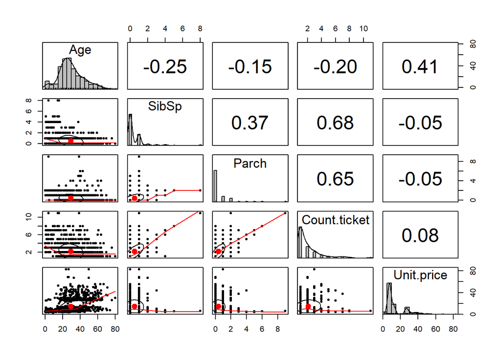

```r
# Relaciones cruzadas de las variables cuantitativas (correlaciones) para todos los datos.

col_var_cuantitativa_sin_ID <- c("Age", "SibSp", "Parch", "Count.ticket", "Unit.price")

df_var_cuantitativa <- df_total_sin_etiqueta[, col_var_cuantitativa_sin_ID]


pairs.panels(df_var_cuantitativa[,col_var_cuantitativa_sin_ID],
             method = "pearson",
             hist.col = "grey",
             density = TRUE,
             ellipses = TRUE
             )
```

**OLGA** Para algunos modelos necesitaremos la variable en forma de texto, por lo tanto guardamos un dato alternativo sobre la supervivencia de los pasajeros: “Survived” para el valor 1 y “Died” para el valor 0 de la variable dependiente.

```r
train$survived <- ifelse(train$Survived==1, "Survived", "Died")
```

```r
X <- train[c("Pclass", "Sex", "Age", "SibSp", "Parch", "Count.ticket", "Unit.price", "Embarked")]

y <- train[9]
y.1 <- train[10]
```

Partimos el conjunto train en subconjuntos de train y validación. De esta manera dispondremos de datos para comprobar el funcionamiento de los modelos que construyamos.

```r
indexes = sample(1:nrow(train), size=floor((2/3)*nrow(train)))
trainX<-X[indexes,]
trainy<-y[indexes,]
validX<-X[-indexes,]
validy<-y[-indexes,]
train.1 <- data.frame(cbind(trainX, trainy))
trainy.1 <- y.1[indexes,]
validy.1 <- y.1[-indexes,]
```

**Regresión**

Aplicamos una regresión logística para predecir la probabilidad de supervivencia usando como variable predictora la variable sexo.

Según los datos que nos proporciona la función `summary` la variable sexo es significativa para predecir la supervivencia y ser de sexo masculino reduce la probabilidad de sobrevivir.

```r
#model0=glm(formula=Survived~Sex, data=train, family=binomial(link=logit))
model0=glm(formula=trainy~Sex, data=train.1, family=binomial(link=logit))

summary(model0)
```

```
##
## Call:
## glm(formula = trainy ~ Sex, family = binomial(link = logit),
##     data = train.1)
##
## Deviance Residuals:
##     Min       1Q   Median       3Q      Max
## -1.6890  -0.6190  -0.6190   0.7412   1.8690
##
## Coefficients:
##             Estimate Std. Error z value Pr(>|z|)
## (Intercept)   1.1516     0.1639   7.027 2.11e-12 ***
## Sexmale      -2.7066     0.2114 -12.806  < 2e-16 ***
## ---
## Signif. codes:  0 '***' 0.001 '**' 0.01 '*' 0.05 '.' 0.1 ' ' 1
##
## (Dispersion parameter for binomial family taken to be 1)
##
##     Null deviance: 786.19  on 593  degrees of freedom
## Residual deviance: 585.86  on 592  degrees of freedom
## AIC: 589.86
##
## Number of Fisher Scoring iterations: 4
```

Calculamos los Odds Ratio. Los odds ratio indican que ser hombre es factor de protección para la clase 1 (sobrevivir). Los hombres están “protegidos” de la supervivencia en comparación con las mujeres.

```r
exp(coefficients(model0))
```

```
## (Intercept)     Sexmale
##  3.16326531  0.06676017
```

```r
newdata <- validX
probabilities <- model0 %>% predict(newdata[c("Sex")], type = "response")
predicted.classes <- ifelse(probabilities > 0.5, 1, 0)

# Matriz de confusión
conf.1 <- table(validy, predicted.classes)
conf.1
```

```
##       predicted.classes
## validy   0   1
##      0 146  32
##      1  41  78
```

```r
# Precisión
sum(diag(conf.1))/sum(colSums(conf.1))
```

```
## [1] 0.7542088
```

Aplicamos una regresión logística para comprobar si las variables Sexo y Clase son significativas para la supervivencia en el accidente.

Ambas variables son significativas y así lo indican los asteriscos junto a los valores Pr(>|z|).

Ser hombre, viajar en clase 2 o clase 3 reduce la posibilidad de supervivencia con respecto a ser mujer y viajar en primera clase. Esto viene indicado por el signo negativo que acompaña el valor del coeficiente para Sexmale, Pclass2 y Pclass3.

```r
model1=glm(formula=trainy~Sex+as.factor(Pclass), data=train.1, family=binomial(link=logit))
summary(model1)
```

```
##
## Call:
## glm(formula = trainy ~ Sex + as.factor(Pclass), family = binomial(link = logit),
##     data = train.1)
##
## Deviance Residuals:
##     Min       1Q   Median       3Q      Max
## -2.1869  -0.7117  -0.4376   0.6317   2.1879
##
## Coefficients:
##                    Estimate Std. Error z value Pr(>|z|)
## (Intercept)          2.2953     0.2711   8.466  < 2e-16 ***
## Sexmale             -2.7544     0.2287 -12.044  < 2e-16 ***
## as.factor(Pclass)2  -0.7850     0.3026  -2.595  0.00947 **
## as.factor(Pclass)3  -1.8385     0.2677  -6.868 6.52e-12 ***
## ---
## Signif. codes:  0 '***' 0.001 '**' 0.01 '*' 0.05 '.' 0.1 ' ' 1
##
## (Dispersion parameter for binomial family taken to be 1)
##
##     Null deviance: 786.19  on 593  degrees of freedom
## Residual deviance: 532.24  on 590  degrees of freedom
## AIC: 540.24
##
## Number of Fisher Scoring iterations: 4
```

Calculamos los odds ratio. Igual que en el caso anterior vemos que la probabilidad ser hombre y sobrevivir es mucho menor que la de ser mujer y sobrevivir. Por clases el OR indica que estar en segunda o tercera clase es factor de protección (pocas probable sobrevivir) respecto a la primera clase.

```r
exp(coefficients(model1))
```

```
##        (Intercept)            Sexmale as.factor(Pclass)2 as.factor(Pclass)3
##         9.92741657         0.06364683         0.45609794         0.15905315
```

Realizamos la predicción sobre el conjunto de validación que obtuvimos y con el resultado creamos una matriz de confusión y calculamos la precisión. El resultado es igual que en la regresión anterior.

```r
probabilities1 <- model1 %>% predict(newdata[c("Sex","Pclass")], type = "response")
predicted.classes1 <- ifelse(probabilities1 > 0.5, 1, 0)
# Matriz de confusión
conf.2 <- table(validy, predicted.classes1)
conf.2
```

```
##       predicted.classes1
## validy   0   1
##      0 146  32
##      1  41  78
```

```r
# Precisión
sum(diag(conf.2)) / sum(colSums(conf.2))
```

```
## [1] 0.7542088
```

```r
model2=glm(formula=trainy~Pclass+Sex+Age+factor(Count.ticket)+Embarked, data=train.1, family=binomial(link=logit))
summary(model2)
```

```
##
## Call:
## glm(formula = trainy ~ Pclass + Sex + Age + factor(Count.ticket) +
##     Embarked, family = binomial(link = logit), data = train.1)
##
## Deviance Residuals:
##     Min       1Q   Median       3Q      Max
## -1.9476  -0.5520  -0.3681   0.5254   2.8416
##
## Coefficients:
##                         Estimate Std. Error z value Pr(>|z|)
## (Intercept)              5.87947    0.74831   7.857 3.93e-15 ***
## Pclass                  -1.25511    0.17990  -6.977 3.02e-12 ***
## Sexmale                 -2.89965    0.27118 -10.693  < 2e-16 ***
## Age                     -0.03899    0.01023  -3.810 0.000139 ***
## factor(Count.ticket)2   -0.19326    0.30729  -0.629 0.529399
## factor(Count.ticket)3    0.53292    0.39192   1.360 0.173906
## factor(Count.ticket)4    1.14917    0.62086   1.851 0.064179 .
## factor(Count.ticket)5   -1.77740    0.75921  -2.341 0.019226 *
## factor(Count.ticket)6   -3.26889    1.06980  -3.056 0.002246 **
## factor(Count.ticket)7   -2.96547    1.08682  -2.729 0.006361 **
## factor(Count.ticket)8    1.22305    0.78323   1.562 0.118391
## factor(Count.ticket)11 -14.95400  642.03793  -0.023 0.981418
## EmbarkedQ               -0.58818    0.49751  -1.182 0.237114
## EmbarkedS               -0.69958    0.30473  -2.296 0.021690 *
## ---
## Signif. codes:  0 '***' 0.001 '**' 0.01 '*' 0.05 '.' 0.1 ' ' 1
##
## (Dispersion parameter for binomial family taken to be 1)
##
##     Null deviance: 786.19  on 593  degrees of freedom
## Residual deviance: 472.26  on 580  degrees of freedom
## AIC: 500.26
##
## Number of Fisher Scoring iterations: 14
```

El resultado del modelo indica que cuando tres o cuatro personas viajaban juntas, la probabilidad de sobrevivir aumentaba (signo positivo del coeficiente).

```r
exp(coefficients(model2))
```

```
##            (Intercept)                 Pclass                Sexmale                    Age  factor(Count.ticket)2  factor(Count.ticket)3  factor(Count.ticket)4  factor(Count.ticket)5  factor(Count.ticket)6  factor(Count.ticket)7  factor(Count.ticket)8 factor(Count.ticket)11              Embarked…
##           3.576209e+02           2.850444e-01           5.504222e-02           9.617591e-01           8.242662e-01           1.703899e+00           3.155580e+00           1.690766e-01           3.804849e-02           5.153636e-02           3.397547e+00           3.203039e-07           5.553388e-0…
```

```r
probabilities2 <- model2 %>% predict(newdata[c("Pclass","Sex","Age","Count.ticket", "Embarked")], type = "response")
predicted.classes2 <- ifelse(probabilities2 > 0.5, 1, 0)
# Matriz de confusión
conf.3 <- table(validy, predicted.classes2)
conf.3
```

```
##       predicted.classes2
## validy   0   1
##      0 150  28
##      1  35  84
```

```r
# Precisión

sum(diag(conf.3)) / sum(colSums(conf.3))
```

```
## [1] 0.7878788
```

**Árboles de decisión CART**

En primer lugar creamos un árbol de decisión para predecir la supervivencia de los pasajeros del Titanic tomando en cuanta las variables explicatovas del conjunto de entrenamiento y la etiqueta de clase (Supervivencia o no)

Usamos los datos del conjunto train para entrenar el modelo y visualizamos el árbol y los datos del modelo.

```r
treeFit <- rpart(trainy~.,data=trainX,method ='class')
print(treeFit)
```

```
## n= 594
##
## node), split, n, loss, yval, (yprob)
##       * denotes terminal node
##
##   1) root 594 223 0 (0.62457912 0.37542088)
##     2) Sex=male 390  68 0 (0.82564103 0.17435897)
##       4) Unit.price< 25.96562 323  44 0 (0.86377709 0.13622291)
##         8) Age>=3.5 312  37 0 (0.88141026 0.11858974) *
##         9) Age< 3.5 11   4 1 (0.36363636 0.63636364) *
##       5) Unit.price>=25.96562 67  24 0 (0.64179104 0.35820896)
##        10) Age>=50.5 18   1 0 (0.94444444 0.05555556) *
##        11) Age< 50.5 49  23 0 (0.53061224 0.46938776)
##          22) Unit.price>=31.09165 22   6 0 (0.72727273 0.27272727) *
##          23) Unit.price< 31.09165 27  10 1 (0.37037037 0.62962963) *
##     3) Sex=female 204  49 1 (0.24019608 0.75980392)
##       6) Pclass>=2.5 87  43 1 (0.49425287 0.50574713)
##        12) Count.ticket>=4.5 12   0 0 (1.00000000 0.00000000) *
##        13) Count.ticket< 4.5 75  31 1 (0.41333333 0.58666667)
##          26) Age>=14.75 58  29 0 (0.50000000 0.50000000)
##            52) Unit.price>=7.9875 13   3 0 (0.76923077 0.23076923) *
##            53) Unit.price< 7.9875 45  19 1 (0.42222222 0.57777778)
##             106) Age>=30.25 7   1 0 (0.85714286 0.14285714) *
##             107) Age< 30.25 38  13 1 (0.34210526 0.65789474) *
##          27) Age< 14.75 17   2 1 (0.11764706 0.88235294) *
##       7) Pclass< 2.5 117   6 1 (0.05128205 0.94871795) *
```

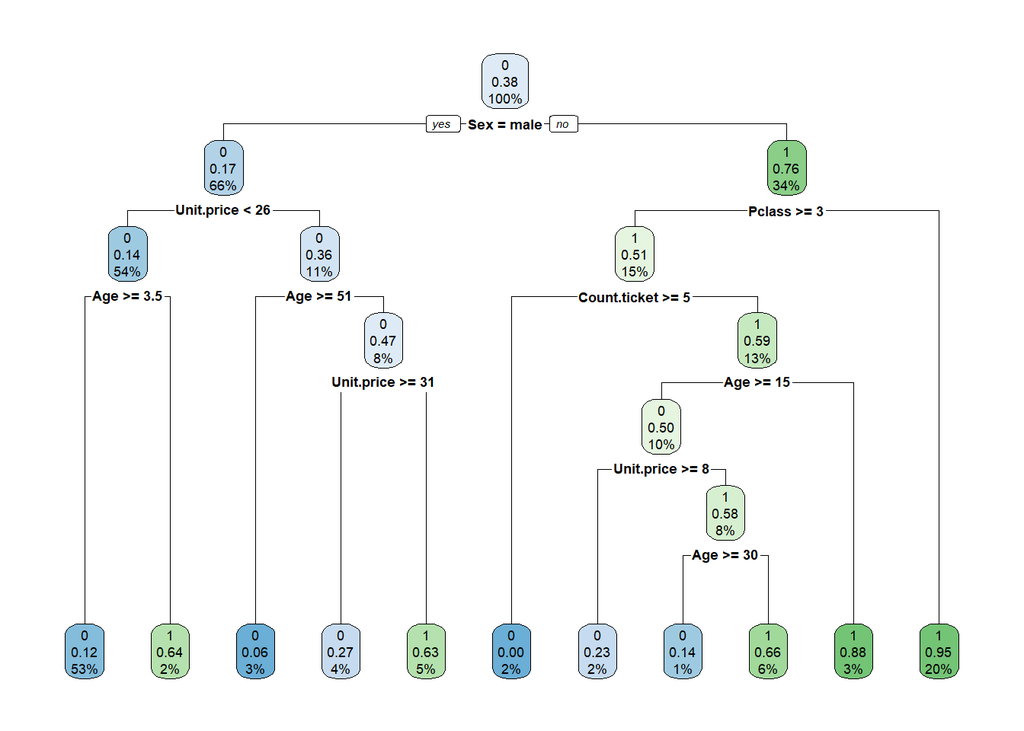

```r
# Árbol resultante.
rpart.plot(treeFit)
```

Predecimos usando los datos de validación.

```r
prediction <- predict(treeFit,newdata=validX,type ='class')
```

Con la matriz de confusión y el valor de Accuracy podemos ver que la predicción ha mejorado con respecto a la regresión logística.

```r
confusionMatrix(prediction,validy)
```

```
## Confusion Matrix and Statistics
##
##           Reference
## Prediction   0   1
##          0 154  32
##          1  24  87
##
##                Accuracy : 0.8114
##                  95% CI : (0.7622, 0.8543)
##     No Information Rate : 0.5993
##     P-Value [Acc > NIR] : 3.721e-15
##
##                   Kappa : 0.603
##
##  Mcnemar's Test P-Value : 0.3496
##
##             Sensitivity : 0.8652
##             Specificity : 0.7311
##          Pos Pred Value : 0.8280
##          Neg Pred Value : 0.7838
##              Prevalence : 0.5993
##          Detection Rate : 0.5185
##    Detection Prevalence : 0.6263
##       Balanced Accuracy : 0.7981
##
##        'Positive' Class : 0
##
```

**Árbol de decisión usando cross validation y búsqueda de mejor parámetro**

Podemos entrenar un árbol de decisión usando cross validation y la búsqueda en rejilla.

```r
library(caret)
library(lattice)

control <-  trainControl(method="repeatedcv", number=3, repeats=3, savePredictions = TRUE)
metric <- "Accuracy"
grid <- expand.grid(cp = seq(0.0001,0.05,0.001))
# Training of model.
model.boost <- train(y=as.factor(trainy), tuneGrid=grid,x=trainX, method="rpart",metric=metric, trControl=control)

# Summarize the results
print(model.boost)
```

```
## CART
##
## 594 samples
##   8 predictor
##   2 classes: '0', '1'
##
## No pre-processing
## Resampling: Cross-Validated (3 fold, repeated 3 times)
## Summary of sample sizes: 397, 395, 396, 397, 396, 395, ...
## Resampling results across tuning parameters:
##
##   cp      Accuracy   Kappa
##   0.0001  0.8131054  0.5934646
##   0.0011  0.8131054  0.5934646
##   0.0021  0.8131054  0.5934646
##   0.0031  0.8142221  0.5953852
##   0.0041  0.8164611  0.6019767
##   0.0051  0.8164611  0.6019767
##   0.0061  0.8164611  0.6019767
##   0.0071  0.8075022  0.5795735
##   0.0081  0.8075022  0.5795735
##   0.0091  0.8091857  0.5811367
##   0.0101  0.8091857  0.5811367
##   0.0111  0.8086274  0.5800257
##   0.0121  0.8097441  0.5803877
##   0.0131  0.8097441  0.5803877
##   0.0141  0.8131083  0.5857678
##   0.0151  0.8131083  0.5857678
##   0.0161  0.8119802  0.5825701
##   0.0171  0.8108522  0.5791310
##   0.0181  0.8108522  0.5791310
##   0.0191  0.8108522  0.5791310
##   0.0201  0.8108522  0.5791310
##   0.0211  0.8130884  0.5853721
##   0.0221  0.8130884  0.5853721
##   0.0231  0.8136467  0.5857656
##   0.0241  0.8097072  0.5798912
##   0.0251  0.8097072  0.5798912
##   0.0261  0.8097072  0.5798912
##   0.0271  0.8074738  0.5754671
```

[output cut: 10 more lines]

```
##   0.0381  0.8035427  0.5712508
##   0.0391  0.8035427  0.5712508
##   0.0401  0.8035427  0.5712508
##   0.0411  0.8029844  0.5722544
##   0.0421  0.8029844  0.5722544
##   0.0431  0.8029844  0.5722544
##   0.0441  0.8029844  0.5722544
##   0.0451  0.8029844  0.5722544
##   0.0461  0.8029844  0.5722544
##   0.0471  0.8029844  0.5722544
##   0.0481  0.8029844  0.5722544
##   0.0491  0.8029844  0.5722544
##
## Accuracy was used to select the optimal model using the largest value.
## The final value used for the model was cp = 0.0061.
```

```r
model.boost$finalModel
```

```
## n= 594
##
## node), split, n, loss, yval, (yprob)
##       * denotes terminal node
##
##   1) root 594 223 0 (0.62457912 0.37542088)
##     2) Sex=male 390  68 0 (0.82564103 0.17435897)
##       4) Unit.price< 25.96562 323  44 0 (0.86377709 0.13622291)
##         8) Age>=3.5 312  37 0 (0.88141026 0.11858974) *
##         9) Age< 3.5 11   4 1 (0.36363636 0.63636364) *
##       5) Unit.price>=25.96562 67  24 0 (0.64179104 0.35820896)
##        10) Age>=50.5 18   1 0 (0.94444444 0.05555556) *
##        11) Age< 50.5 49  23 0 (0.53061224 0.46938776)
##          22) Unit.price>=31.09165 22   6 0 (0.72727273 0.27272727) *
##          23) Unit.price< 31.09165 27  10 1 (0.37037037 0.62962963) *
##     3) Sex=female 204  49 1 (0.24019608 0.75980392)
##       6) Pclass>=2.5 87  43 1 (0.49425287 0.50574713)
##        12) Count.ticket>=4.5 12   0 0 (1.00000000 0.00000000) *
##        13) Count.ticket< 4.5 75  31 1 (0.41333333 0.58666667)
##          26) Age>=14.75 58  29 0 (0.50000000 0.50000000)
##            52) Unit.price>=7.9875 13   3 0 (0.76923077 0.23076923) *
##            53) Unit.price< 7.9875 45  19 1 (0.42222222 0.57777778)
##             106) Age>=30.25 7   1 0 (0.85714286 0.14285714) *
##             107) Age< 30.25 38  13 1 (0.34210526 0.65789474)
##               214) Unit.price< 7.6396 14   6 0 (0.57142857 0.42857143) *
##               215) Unit.price>=7.6396 24   5 1 (0.20833333 0.79166667) *
##          27) Age< 14.75 17   2 1 (0.11764706 0.88235294) *
##       7) Pclass< 2.5 117   6 1 (0.05128205 0.94871795) *
```

```r
prediction <- ifelse(predict(model.boost$finalModel, newdata=validX)[,1]>0.50, "0", "1")

table(prediction, validy)
```

```
##           validy
## prediction   0   1
##          0 157  41
##          1  21  78
```

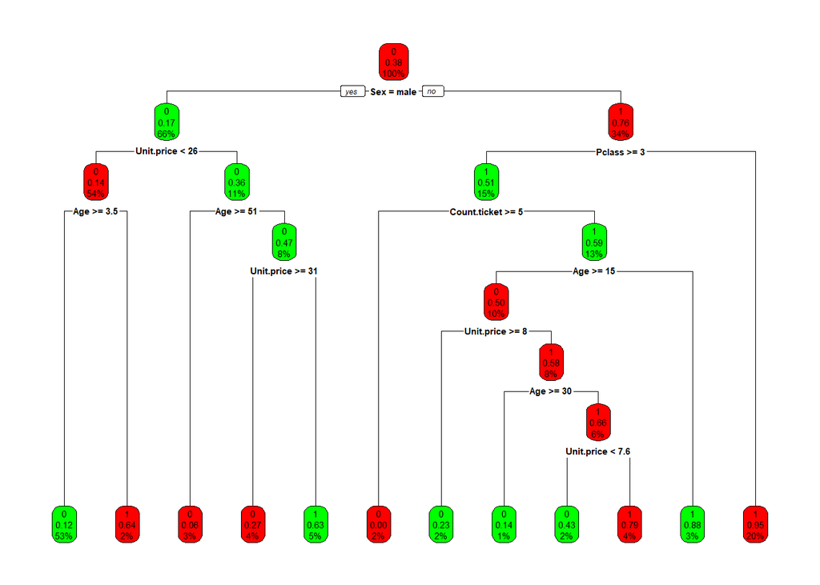

```r
rpart.plot(model.boost$finalModel, box.col=c("red", "green"))
```

```r
model.boost$levels
```

```
## [1] "0" "1"
## attr(,"ordered")
## [1] FALSE
```

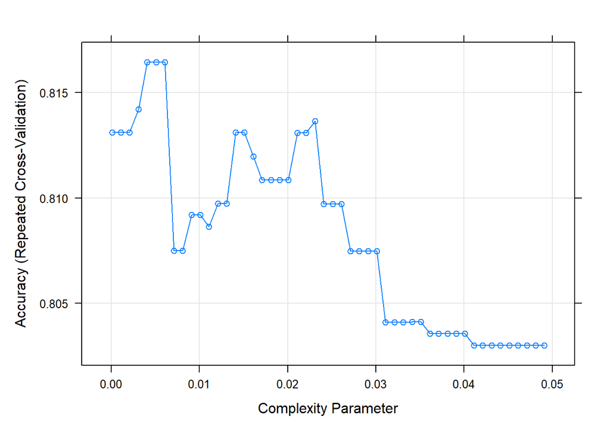

```r
plot(model.boost)
```

```r
predicted_model.boost <- predict(model.boost, newdata=validX)
cmat <- confusionMatrix(predicted_model.boost, as.factor(validy))
cmat
```

```
## Confusion Matrix and Statistics
##
##           Reference
## Prediction   0   1
##          0 157  41
##          1  21  78
##
##                Accuracy : 0.7912
##                  95% CI : (0.7405, 0.836)
##     No Information Rate : 0.5993
##     P-Value [Acc > NIR] : 1.485e-12
##
##                   Kappa : 0.5529
##
##  Mcnemar's Test P-Value : 0.01582
##
##             Sensitivity : 0.8820
##             Specificity : 0.6555
##          Pos Pred Value : 0.7929
##          Neg Pred Value : 0.7879
##              Prevalence : 0.5993
##          Detection Rate : 0.5286
##    Detection Prevalence : 0.6667
##       Balanced Accuracy : 0.7687
##
##        'Positive' Class : 0
##
```

```r
#Defining the training controls for multiple models
fitControl <- trainControl(
  method = "repeatedcv",
  number = 5,
  repeats = 3,
savePredictions = 'final',
classProbs = T)

#Defining the predictors and outcome
predictors<-colnames(trainX)
```

```r
#Training the random forest model
#model_rf<-train(trainX,y=as.factor(trainy.1),method='rf',trControl=fitControl,tuneLength=9)

#Predicting using random forest model
#validX$pred_rf<-predict(object = model_rf,validX)

#Checking the accuracy of the random forest model
#confusionMatrix(as.factor(validy.1),validX$pred_rf)
```

```r
#plot(model_rf)
```

# 5 **Representación de resultados**

## 5.1 Tabla resumen de las variables cualitativas (datos completos)

Realizaremos una tabla resumen con las frecuencias relativas y las frecuencias absolutas de las variables cualitativas. Creamos un dataframe auxiliar para generar nuestra tabla.

Calculamos, para todos los campos, la frecuencia relativa y absoluta a través del contaje dividido por el número total de filas del dataframe.

Creamos una tabla mediante la función kable().

```r
col_var_cualitativa_sin_ID <- c("Pclass", "Sex", "Embarked")

df_var_cualitativa <- df_total_sin_etiqueta[, col_var_cualitativa_sin_ID]

df_var_cualitativa$Sex <- as.factor(df_var_cualitativa$Sex)
df_var_cualitativa$Embarked <- as.factor(df_var_cualitativa$Embarked)


# Frecuencias relativas y absolutas de campo PClass
Pclass_table_frec <- (count(df_var_cualitativa$Pclass))
Pclass_table_cum <- (count(df_var_cualitativa$Pclass)/dim(df_var_cualitativa)[1])[2]

Pclass_table <- cbind (Pclass_table_frec, Pclass_table_cum)

# Frecuencias relativas y absolutas de campo Sex
Sex_table_frec <- (count(df_var_cualitativa$Sex))
Sex_table_cum <- (count(df_var_cualitativa$Sex)/dim(df_var_cualitativa)[1])[2]

Sex_table <- cbind (Sex_table_frec, Sex_table_cum)

# Frecuencias relativas y absolutas de campo Embarked
Embarked_table_frec <- (count(df_var_cualitativa$Embarked))
Embarked_table_cum <- (count(df_var_cualitativa$Embarked)/dim(df_var_cualitativa)[1])[2]

Embarked_table <- cbind (Embarked_table_frec, Embarked_table_cum)



# Unión de toda la tabla asignando el nombre de las columnas
df_var_cualitativa_table <- rbind.data.frame(Pclass_table, Sex_table, Embarked_table)
colnames(df_var_cualitativa_table) <- c("Variable Cualitativa", "Frecuencia Absoluta", "Frecuencia Relativa")

# Variables auxiliares para la creación de la tabla kable() de forma más automática.

# Dimensiones de cada grupo de la tabla
dim_grupo1_ = length(unique(df_var_cualitativa$Pclass))
dim_grupo2_ = length(unique(df_var_cualitativa$Sex))
dim_grupo3_ = length(unique(df_var_cualitativa$Embarked))



# Límites de las posiciones de los grupos (automatico)
dim1_i <- 1
dim1_f <- dim_grupo1_
dim2_i <- dim1_f +1
dim2_f <- dim_grupo1_ + dim_grupo2_
dim3_i <- dim2_f +1
dim3_f <- dim_grupo1_ + dim_grupo2_ + dim_grupo3_



# Formato de la tabla mediante función kable()
# Formato de los dígitos de los campos
# Creación del título de la tabla y anotación
kable(df_var_cualitativa_table, digits = c(0,0,3), caption = "-TABLA RESUMEN DE LAS VARIABLES CUALITATIVAS-
      <p> (Total observaciones: 1309. Suma de frecuencias relativas sin redondeo = 1.000)") %>%
  kable_styling("striped",
                full_width = F) %>%
  pack_rows("Clases Embarque",
            dim1_i,
            dim1_f,
            label_row_css = "background-color: #666; color: #fff;") %>%
  pack_rows("Sexo",
            dim2_i,
            dim2_f,
            label_row_css = "background-color: #666; color: #fff;") %>%
  pack_rows("Embarque",
            dim3_i,
            dim3_f,
            label_row_css = "background-color: #666; color: #fff;")
```

-TABLA RESUMEN DE LAS VARIABLES CUALITATIVAS- (Total observaciones: 1309. Suma de frecuencias relativas sin redondeo = 1.000)

| Variable Cualitativa | Frecuencia Absoluta | Frecuencia Relativa |
| --- | --- | --- |
| **Clases Embarque** |  |  |
| 1 | 323 | 0.247 |
| 2 | 277 | 0.212 |
| 3 | 709 | 0.542 |
| **Sexo** |  |  |
| female | 466 | 0.356 |
| male | 843 | 0.644 |
| **Embarque** |  |  |
| C | 270 | 0.206 |
| Q | 123 | 0.094 |
| S | 916 | 0.700 |

## 5.2 Tabla resumen de las variables cuantitativas (datos completos)

Realizaremos una tabla resumen con los estadísticos principales de tendencia central y dispersión, con medidas robustas y no robustas. Para ello, utilizaremos tres funciones que nos aportarán diferentes estadísticos a utilizar:

describe() winsor.mean() (aplicaremos unos límites del 5 %). stat.desc() Estas tres funciones nos darán diversos estadísticos que uniremos y ordenaremos en una única tabla para mostrar un completo resumen estadístico de las variables cuantitativas.

Finalmente, creamos una tabla mediante la función kable().

```r
# Creación tabla con describe()
col_var_cuantitativa_sin_ID <- c("Age", "SibSp", "Parch", "Count.ticket", "Unit.price")

df_var_cuantitativa <- df_total_sin_etiqueta[, col_var_cuantitativa_sin_ID]

df_var_cuantitativa_tabla <- describe(df_var_cuantitativa, quant = TRUE, IQR = TRUE)

# Creación tabla con winsor.mean()
winsor <- data.frame(t(winsor.mean(df_var_cuantitativa, trim= 0.05)))
winsor_df <- data.frame(t(winsor))
colnames(winsor_df) <- c("Winsor Mean 5%")

# Unión tablas describe() con winsor.mean()
df_var_cuantitativa_tabla$Winsor_Mean_.5 <- winsor_df$`Winsor Mean 5%`

# Eliminación campos no usables
df_var_cuantitativa_tabla <- df_var_cuantitativa_tabla[, -c(1, 11, 12, 15 )]

# Cambio de nombres de los campos
colnames(df_var_cuantitativa_tabla) <- c("Number", "Mean", "St_Dev", "Median", "Trimmed_Median", "MAD", "Min", "Max", "Range", "SE_Mean", "IQR", "Winsor_Mean_0.5")

df_var_cuantitativa_tabla
```

```
##              Number  Mean St_Dev Median Trimmed_Median   MAD  Min   Max Range SE_Mean   IQR Winsor_Mean_0.5
## Age            1309 29.56  13.88   27.0          28.93 11.86 0.17 80.00 79.83    0.38 16.00           29.47
## SibSp          1309  0.50   1.04    0.0           0.27  0.00 0.00  8.00  8.00    0.03  1.00            0.39
## Parch          1309  0.39   0.87    0.0           0.18  0.00 0.00  9.00  9.00    0.02  0.00            0.34
## Count.ticket   1309  2.10   1.78    1.0           1.69  0.00 1.00 11.00 10.00    0.05  2.00            2.01
## Unit.price     1309 14.69  11.99    8.3          12.40  3.26 3.17 82.51 79.34    0.33  7.33           14.24
```

```r
options(digits=2)

# Creación tabla con stat.desc()
df_var_cuantitativa_tabla2 <- as.data.frame(t(round(stat.desc(df_var_cuantitativa),2)))

# Cambio de nombres de los campos
colnames(df_var_cuantitativa_tabla2) <- c("tot_num", "NUll", "NA", "Min_", "Max_", "Range_", "sum", "median_", "mean_", "se_mean_", "CI_Mean_0.95", "Var", "stddev_", "Coef_Var")

# Eliminación campos no usables
df_var_cuantitativa_tabla2 <- df_var_cuantitativa_tabla2[, -c(1, 2, 4, 5, 6 ,7, 8, 9, 10, 13)]
df_var_cuantitativa_tabla2
```

```
##              NA CI_Mean_0.95    Var Coef_Var
## Age           0         0.75 192.67     0.47
## SibSp         0         0.06   1.09     2.09
## Parch         0         0.05   0.75     2.25
## Count.ticket  0         0.10   3.17     0.85
## Unit.price    0         0.65 143.86     0.82
```

```r
# Unión tablas describe()/winsor.mean() con tabla stat.desc()
counterdf_cuan <- c(1:dim(df_var_cuantitativa_tabla2)[2])
df_var_cuantitativa_tabla_dim_ini <- dim(df_var_cuantitativa_tabla)[2]

for (i in counterdf_cuan){
      df_var_cuantitativa_tabla[i+df_var_cuantitativa_tabla_dim_ini] <- df_var_cuantitativa_tabla2[i]
     }

# Reordenamiento de las columnas para poder agrupar los campos for temática: tendencia central, dispersión, robusta y no robusta
df_var_cuantitativa_tabla <- df_var_cuantitativa_tabla[, c(2, 10, 14, 4, 5, 12, 15, 16, 3, 6, 11, 1, 13, 7, 8, 9)]


# Creación del dataframe haciendo la transpuesta de la tabla anterior para tener los estadisticos en las fila y las variables en las columnas.
df_var_cuantitativa_tabla <- data.frame(t(df_var_cuantitativa_tabla))
df_var_cuantitativa_tabla
```

```
##                     Age   SibSp   Parch Count.ticket Unit.price
## Mean              29.56 5.0e-01 3.9e-01      2.1e+00      14.69
## SE_Mean            0.38 2.9e-02 2.4e-02      4.9e-02       0.33
## CI_Mean_0.95       0.75 6.0e-02 5.0e-02      1.0e-01       0.65
## Median            27.00 0.0e+00 0.0e+00      1.0e+00       8.30
## Trimmed_Median    28.93 2.7e-01 1.8e-01      1.7e+00      12.40
## Winsor_Mean_0.5   29.47 3.9e-01 3.4e-01      2.0e+00      14.24
## Var              192.67 1.1e+00 7.5e-01      3.2e+00     143.86
## Coef_Var           0.47 2.1e+00 2.2e+00      8.5e-01       0.82
## St_Dev            13.88 1.0e+00 8.7e-01      1.8e+00      11.99
## MAD               11.86 0.0e+00 0.0e+00      0.0e+00       3.26
## IQR               16.00 1.0e+00 0.0e+00      2.0e+00       7.33
## Number          1309.00 1.3e+03 1.3e+03      1.3e+03    1309.00
## NA                 0.00 0.0e+00 0.0e+00      0.0e+00       0.00
## Min                0.17 0.0e+00 0.0e+00      1.0e+00       3.17
## Max               80.00 8.0e+00 9.0e+00      1.1e+01      82.51
## Range             79.83 8.0e+00 9.0e+00      1.0e+01      79.34
```

```r
# Creación de la tabla mediante kable()

# Formato numérico no científico
options(scipen = 999)

# Variables auxiliares para la creación de la tabla kable() de forma más automática.
# Dimensiones de cada grupo de la tabla
dim_grupo1 = 3
dim_grupo2 = 3
dim_grupo3 = 3
dim_grupo4 = 2
dim_grupo5 = 5

# Límites de las posiciones de los grupos (automatico)
dim1_i <- 1
dim1_f <- dim_grupo1
dim2_i <- dim1_f +1
dim2_f <- dim_grupo1 + dim_grupo2
dim3_i <- dim2_f +1
dim3_f <- dim_grupo1 + dim_grupo2 + dim_grupo3
dim4_i <- dim3_f +1
dim4_f <- dim_grupo1 + dim_grupo2 + dim_grupo3 + dim_grupo4
dim5_i <- dim4_f +1
dim5_f <- dim_grupo1 + dim_grupo2 + dim_grupo3 + dim_grupo4 + dim_grupo5

# Formato de la tabla mediante función kable()
# Formato de los dígitos de los campos
# Creación del título de la tabla y anotación
kable(df_var_cuantitativa_tabla, digits = c(2, 2, 2, 3), caption = "-TABLA RESUMEN DE LAS VARIABLES CUANTITATIVAS-
      <p> (Total observaciones: 1309.)") %>%
  kable_styling("striped",  full_width = F) %>%
  pack_rows("Tendencia Central (medidas  NO robustas)",
            dim1_i,
            dim1_f,
            label_row_css = "background-color: #666; color: #fff;") %>%
  pack_rows("Tendencia Central (medidas robustas)",
            dim2_i,
            dim2_f,
            label_row_css = "background-color: #666; color: #fff;") %>%
  pack_rows("Dispersion (medidas NO robustas)",
            dim3_i,
            dim3_f,
            label_row_css = "background-color: #666; color: #fff;") %>%
  pack_rows("Dispersion (medidas robustas)",
            dim4_i,
            dim4_f,
            label_row_css = "background-color: #666; color: #fff;") %>%
  pack_rows("Información Adicional", dim5_i, dim5_f ,label_row_css = "background-color: #666; color: #fff;")
```

-TABLA RESUMEN DE LAS VARIABLES CUANTITATIVAS- (Total observaciones: 1309.)

|  | Age | SibSp | Parch | Count.ticket | Unit.price |
| --- | --- | --- | --- | --- | --- |
| **Tendencia Central (medidas NO robustas)** |  |  |  |  |  |
| Mean | 29.56 | 0.50 | 0.39 | 2.102 | 14.69 |
| SE_Mean | 0.38 | 0.03 | 0.02 | 0.049 | 0.33 |
| CI_Mean_0.95 | 0.75 | 0.06 | 0.05 | 0.100 | 0.65 |
| **Tendencia Central (medidas robustas)** |  |  |  |  |  |
| Median | 27.00 | 0.00 | 0.00 | 1.000 | 8.30 |
| Trimmed_Median | 28.93 | 0.27 | 0.18 | 1.689 | 12.40 |
| Winsor_Mean_0.5 | 29.47 | 0.39 | 0.34 | 2.008 | 14.24 |
| **Dispersion (medidas NO robustas)** |  |  |  |  |  |
| Var | 192.67 | 1.09 | 0.75 | 3.170 | 143.86 |
| Coef_Var | 0.47 | 2.09 | 2.25 | 0.850 | 0.82 |
| St_Dev | 13.88 | 1.04 | 0.87 | 1.780 | 11.99 |
| **Dispersion (medidas robustas)** |  |  |  |  |  |
| MAD | 11.86 | 0.00 | 0.00 | 0.000 | 3.26 |
| IQR | 16.00 | 1.00 | 0.00 | 2.000 | 7.33 |
| **Información Adicional** |  |  |  |  |  |
| Number | 1309.00 | 1309.00 | 1309.00 | 1309.000 | 1309.00 |
| NA | 0.00 | 0.00 | 0.00 | 0.000 | 0.00 |
| Min | 0.17 | 0.00 | 0.00 | 1.000 | 3.17 |
| Max | 80.00 | 8.00 | 9.00 | 11.000 | 82.51 |
| Range | 79.83 | 8.00 | 9.00 | 10.000 | 79.34 |

```r
# Creación tabla con describe()
#col_var_cuantitativa_ID <- c("Age", "SibSp", "Parch", "Fare")

#df_var_cuantitativa <- df_total_sin_etiqueta[, col_var_cuantitativa_ID]

#df_var_cuantitativa_tabla <- describe(df_var_cuantitativa, quant = TRUE, IQR = TRUE)

# Eliminación campos no usables
#df_var_cuantitativa_tabla <- df_var_cuantitativa_tabla[, -c(1, 2, 6, 7, 8, 9, 10, 11, 12, 13, 15)]

# Cambio de nombres de los campos
#colnames(df_var_cuantitativa_tabla) <- c("Mean", "St_Dev", "Median","IQR")

# Transpuesta de la matriz
#df_var_cuantitativa_tabla <- data.frame(t(df_var_cuantitativa_tabla))
```

```r
# Selección/Filtrado de las instancias que solamente pertenecen a US
# Creación de la tabla mediante kable()

# Formato numérico no científico
#options(scipen = 999)

# Variables auxiliares para la creación de la tabla kable() de forma más automática.
# Dimensiones de cada grupo de la tabla
#dim_grupo1 = 4


# Límites de las posiciones de los grupos (automatico)
#dim1_i <- 1
#dim1_f <- dim_grupo1


# Formato de la tabla mediante función kable()
# Formato de los dígitos de los campos
# Creación del título de la tabla y anotación
#kable(df_var_cuantitativa_tabla, digits = c(2, 2, 2, 2, 2, 2, 2), caption = "TABLA RESUMEN DE LAS VARIABLES CUANTITATIVAS (Total observaciones: 400)
#            __________________________________________________________________________________
#      <p>   Sales:         Ventas unitarias, en miles, en cada ubicación
#      <p>   CompPrice:     Precio que cobra el competidor en cada ubicación
#      <p>   Income:        Nivel de ingresos comunitarios, en miles de dólares
#      <p>   Advertising:   Presupuesto de publicidad local de la empresa en cada ubicación, en miles de dólares
#      <p>   Population:    Tamaño de la población en la región, en miles
#      <p>   Price:         Precio del producto en cada ubicación
#      <p>   Age:           Edad media de la población local") %>%
#
#  kable_styling("striped",  full_width = T) %>%
#  pack_rows("Datos Cuantitativos",
#            dim1_i,
#            dim1_f,
#            label_row_css = "background-color: #666; color: #fff;")
```

# 6 **Resolución del problema**

# 7 **Creación del archivo preprocesado**

```r
# Guardamos el archivo con el nombre Titanic_processed.csv
#write.csv(df, "Titanic_processed.csv", row.names = FALSE)
```

```r
contrib <- data.frame(rbind(c("Investigación Previa", "Olga Garcés / Carlos Acosta"),
                            c("Redacción de las respuestas", "Olga Garcés / Carlos Acosta"),
                            c("Desarrollo código", "Olga Garcés / Carlos Acosta")))
colnames(contrib) <- c("Contribuciones", "Firma")

contrib
```

```
##                Contribuciones                       Firma
## 1        Investigación Previa Olga Garcés / Carlos Acosta
## 2 Redacción de las respuestas Olga Garcés / Carlos Acosta
## 3           Desarrollo código Olga Garcés / Carlos Acosta
```